# EDA Master Control

Author

Josh, Joel, Corinn, Gaby

Published

February 17, 2026

# Introduction

### Business Problem

MasterControl is a SaaS provider offering two core software suites: *QX (Quality Solutions)* and *MX (Manufacturing Solutions)*. While QX has over 20 years of market maturity, MX is a newer offering launched approximately four years ago. MX currently underperforms QX with a 12.7% lead progression rate, compared to 19.7% for QX. Leadership believes the current targeting strategy results in sales pursuing leads that are less likely to convert, creating missed opportunities and inefficient resource allocation.

### Analytic Problem

Our analytic task is to identify the **industries**, **company characteristics**, and **job titles** associated with higher MX progression rates. The target variable is **Lead Outcome**, where a lead is considered successful if it reached **SQL**, **SQO**, or **Won**.

The goal of EDA is to:  
- Understand the structure and quality of the data  
- Examine relationships between lead attributes and Lead Outcome  
- Identify which features appear predictive and should be prioritized in modeling  
- Detect missingness, inconsistency, and outlier behavior

### Scope

The output of this project will be recommendations for: - Which industries to target  
- Which job titles represent high-value decision makers  
- How Marketing and Sales can prioritize outreach for the MX product  
- Improvements to prospect data-capture on the MasterControl website

Predicting churn or customer retention is **out of scope**.

### Success Metrics

- **Primary metric:** Lead progression rate (SQL/SQO/Won)
- **Goal:** Increase MX progression from **12.7% → 16–18%**, moving toward the QX benchmark of 19.7%

Success means enabling MasterControl Sales to focus on high-potential profiles that historically progress at above-average rates.

### Project Management

Team members include **Corinn, Josh, Joel, and Gaby**, meeting weekly with the following milestones:  
- Feb 1 — Business problem statement finalized  
- Feb 22 — EDA complete  
- Mar 22 — Modeling & evaluation  
- Apr 8 — Final presentation

### Questions to Guide EDA

1. **Data Quality**
   - What variables exist? How many leads?
   - Are job titles and industry columns clean or messy?
   - Which variables have missing values?
   - Is the missing data random, or does it follow a pattern?
   - Are there any duplicate leads?
2. **Target Variable**
   - What is the overall MX success rate?
   - Is the target imbalanced?
3. **Job Titles**
   - Which job title patterns (e.g., Director, Manager, Engineer) appear most in converted leads?
   - Which technical/manufacturing roles convert best?
4. **Industry**
   - Which industries show the highest conversion rates?
   - Are specific NAICS groups highly predictive?
   - Can differences between conversion rates of the products be explained by industry differences?
5. **Account Characteristics**
   - Do company size, revenue, or region relate to successful MX outcomes?
6. **Interactions**
   - Do specific title + industry combinations show high conversion?
7. **Modeling Implications**
   - Which variables look most promising?
   - Which variables need transformations or cleaning?

# Data Exploration

### Setup

```r
# install.packages
pacman::p_load(tidyverse,stringr,tidytext,quanteda,quanteda.textplots,janitor,skimr,recipes,
               cluster,factoextra,FactoMineR,proxy,dendextend,pheatmap,Rtsne,fpc)
```

### Load Data

```r
# Load Data
leads <- read_csv("Mastercontrol QAL Performance.csv")


# Basic structure
dim(leads)
```

```
[1] 16644    14
```

```r
glimpse(leads)
```

```
Rows: 16,644
Columns: 14
$ `acct primary site function`   <chr> "Food and beverage", "Surgical instrume…
$ `acct manufacturing model`     <chr> "Consumer Packaged Goods", "In-House", …
$ `acct target industry`         <chr> "Non-Life Science", "Medical Device", "…
$ `contact/lead title`           <chr> "QA Manager", "Quality Manager", "ING",…
$ `QAL ID`                       <chr> "a0dPQ000005WbfuYAC", "a0dPQ00000CRpkLY…
$ `contact/lead id`              <chr> "0030c00002XPeNGAA1", "0030c00002ZaC9pA…
$ next_stage__c                  <chr> "SQL", "Won", "Recycled", "Recycled", "…
$ Priority                       <chr> "P1 - Webinar Demo", "Priority 2", "Pri…
$ `acct territory rollup`        <chr> "Americas", "Americas", "EMEA", "Americ…
$ `acct tier rollup`             <chr> "Medium", "Medium", "Large", "Medium", …
$ solution                       <chr> "Mx", "Mx", "Qx", "Logbooks", "Qx", "Qx…
$ solution_rollup                <chr> "Mx", "Mx", "Qx", "Mx", "Qx", "Qx", "Qx…
$ `last tactic campaign channel` <chr> "Online Ads", "SEO", "Email", "External…
$ `qal cohort date`              <date> 2025-06-16, 2025-11-13, 2024-02-15, 20…
```

```r
# Clean column names for easier coding
leads <- clean_names(leads)
names(leads)
```

```
 [1] "acct_primary_site_function"   "acct_manufacturing_model"
 [3] "acct_target_industry"         "contact_lead_title"
 [5] "qal_id"                       "contact_lead_id"
 [7] "next_stage_c"                 "priority"
 [9] "acct_territory_rollup"        "acct_tier_rollup"
[11] "solution"                     "solution_rollup"
[13] "last_tactic_campaign_channel" "qal_cohort_date"
```

```r
# Quick preview
head(leads)
```

```
# A tibble: 6 × 14
  acct_primary_site_function     acct_manufacturing_model   acct_target_industry
  <chr>                          <chr>                      <chr>
1 Food and beverage              Consumer Packaged Goods    Non-Life Science
2 Surgical instruments           In-House                   Medical Device
3 Cell therapies (CAR-T, NK)     Hospital Investigational … Blood & Biologics
4 In-vitro diagnostic (IVD) kits In-House                   Medical Device
5 Nutraceutical manufacturing    CMO                        Pharma & BioTech
6 Diagnostic Equipment           In-House                   Medical Device
# ℹ 11 more variables: contact_lead_title <chr>, qal_id <chr>,
#   contact_lead_id <chr>, next_stage_c <chr>, priority <chr>,
#   acct_territory_rollup <chr>, acct_tier_rollup <chr>, solution <chr>,
#   solution_rollup <chr>, last_tactic_campaign_channel <chr>,
#   qal_cohort_date <date>
```

```r
# Basic summary statistics
summary(leads)
```

```
 acct_primary_site_function acct_manufacturing_model acct_target_industry
 Length:16644               Length:16644             Length:16644
 Class :character           Class :character         Class :character
 Mode  :character           Mode  :character         Mode  :character



 contact_lead_title    qal_id          contact_lead_id    next_stage_c
 Length:16644       Length:16644       Length:16644       Length:16644
 Class :character   Class :character   Class :character   Class :character
 Mode  :character   Mode  :character   Mode  :character   Mode  :character



   priority         acct_territory_rollup acct_tier_rollup     solution
 Length:16644       Length:16644          Length:16644       Length:16644
 Class :character   Class :character      Class :character   Class :character
 Mode  :character   Mode  :character      Mode  :character   Mode  :character



 solution_rollup    last_tactic_campaign_channel qal_cohort_date
 Length:16644       Length:16644                 Min.   :2024-01-01
 Class :character   Class :character             1st Qu.:2024-05-22
 Mode  :character   Mode  :character             Median :2024-11-27
                                                 Mean   :2024-11-29
                                                 3rd Qu.:2025-05-30
                                                 Max.   :2025-12-31
```

```r
# Check missing values
colSums(is.na(leads))
```

```
  acct_primary_site_function     acct_manufacturing_model
                          60                          101
        acct_target_industry           contact_lead_title
                          45                         4861
                      qal_id              contact_lead_id
                           0                            3
                next_stage_c                     priority
                         394                            0
       acct_territory_rollup             acct_tier_rollup
                         132                           45
                    solution              solution_rollup
                           0                            0
last_tactic_campaign_channel              qal_cohort_date
                           0                            0
```

```r
#view data set
#view(leads)

# Check for duplicate rows by qal_id
sum(duplicated(leads$qal_id))
```

```
[1] 0
```

```r
# Check which leads are duplicated
leads$qal_id[duplicated(leads$qal_id)]
```

```
character(0)
```

### Dataset Overview

**Account / site context:**

- **acct_primary_site_function:** describes the primary activity at the customer site (e.g., Food and beverage, Small-molecule API, Sterile injectables).
- **acct_manufacturing_model:** indicates how manufacturing is managed (e.g., Consumer Packaged Goods, In-House, Hospital/Investor model).
- **acct_target_industry:** the industry segment of the account (e.g., Pharma & BioTech, Medical Device, Non-Life Science).

**Contact-level information:**

- **contact_lead_title:** the job title of the lead or contact (e.g., QA Manager, VP Quality & Regulatory Affairs).
- **contact_lead_id:** identifier for the individual contact; may repeat if a person is tied to multiple QAL records.

**QAL identifiers and lead outcomes:**

- **qal_id:** unique identifier for the QAL record.
- **next_stage_c:** the lead outcome or progression stage (e.g., SQL, SQO, Won, Recycled). This is our target variable identifier. This will be converted into a binary success indicator for modeling.

**Account segmentation and territory:**

- **acct_territory_rollup:** geographic region (Americas, EMEA, APAC & Oceania).
- **acct_tier_rollup:** account size/tier (Small, Medium, Large), useful for segmentation.

**Product and marketing channel:**

- **solution:** specific MasterControl product family engaged (Mx, Qx, Ax, Logbooks).
- **solution_rollup:** product family grouping used to distinguish MX from QX.
- **last_tactic_campaign_channel:** most recent marketing touchpoint (e.g., Email, Online Ads, Outbound Prospecting).

**Time**

All variables except the cohort date are categorical and will be treated as factors during modeling. The dataset includes a mix of account attributes, contact information, product engagement, and progression outcomes—providing multiple angles to explore what drives higher MX success. There are 0 duplicated leads in the dataset, meaning every qal_id is unique, therefore no leads were imputed twice and will only be counted once in analysis. The next step is to evaluate missingness and data quality across these fields to understand how each variable will behave in downstream analysis.

### Missing Data

```r
# Count missing values per column
missing_values <- leads %>%
  summarise(across(everything(), ~ sum(is.na(.)))) %>%
  pivot_longer(cols = everything(),
               names_to = "variable",
               values_to = "n_missing") %>%
  mutate(
    pct_missing = 100 * n_missing / nrow(leads)
  ) %>%
  arrange(desc(pct_missing))

missing_values
```

```
# A tibble: 14 × 3
   variable                     n_missing pct_missing
   <chr>                            <int>       <dbl>
 1 contact_lead_title                4861     29.2
 2 next_stage_c                       394      2.37
 3 acct_territory_rollup              132      0.793
 4 acct_manufacturing_model           101      0.607
 5 acct_primary_site_function          60      0.360
 6 acct_target_industry                45      0.270
 7 acct_tier_rollup                    45      0.270
 8 contact_lead_id                      3      0.0180
 9 qal_id                               0      0
10 priority                             0      0
11 solution                             0      0
12 solution_rollup                      0      0
13 last_tactic_campaign_channel         0      0
14 qal_cohort_date                      0      0
```

#### Missing Data Overview

Low missingness (less than 0.3%) appears in:

- **acct_target_industry (45 missing)**
- **acct_tier_rollup (45 missing)**
- **contact_lead_id (3 missing)**

These complete variables can be used reliably for segmentation and cohort-based analysis.

Overall, the missing data pattern indicates that contact and site-level details are inconsistently collected, while product, territory, and outcome fields are much more complete. For modeling, we will likely need to consolidate missing categories rather than impute them, since these fields represent high-cardinality categorical attributes.

#### Verify Missing Values

According to the data dictionary, the percentage of missing information across variables is minimal, with the exception of job titles. Specifically, the documentation reports:

- **contact/lead title:** 29.21% missing
- **next_stage__c:** 2.37% missing
- **acct_territory_rollup:** 0.79% missing
- **acct_manufacturing_model:** 0.61% missing
- **acct_primary_site_function:** 0.36% missing
- **All other variables:** less than 0.3% missing

Based on this documentation, account-level variables such as industry, manufacturing model, and site function are expected to be highly complete and reliable for segmentation analysis.

To validate these assumptions, we will verify whether the dataset used in this analysis reflects the same missingness levels reported in the data dictionary.

```r
# Check blank strings (optional)
sum(leads$acct_primary_site_function == "", na.rm = TRUE)
```

```
[1] 0
```

```r
sum(leads$acct_manufacturing_model == "", na.rm = TRUE)
```

```
[1] 0
```

```r
dict_missing <- tibble::tribble(
  ~variable, ~dict_pct_missing,
  "contact_lead_title", 29.21,
  "next_stage_c", 2.37,
  "acct_territory_rollup", 0.79,
  "acct_manufacturing_model", 0.61,
  "acct_primary_site_function", 0.36,
  "acct_tier_rollup", 0.27,
  "acct_target_industry", 0.27,
  "contact_lead_id", 0.02
)

compare_missing <- na_summary %>%
  left_join(dict_missing, by = "variable") %>%
  mutate(diff_pct = round(pct_missing - dict_pct_missing, 2)) %>%
  arrange(desc(pct_missing))

compare_missing
```

```
# A tibble: 14 × 5
   variable                     n_missing pct_missing dict_pct_missing diff_pct
   <chr>                            <int>       <dbl>            <dbl>    <dbl>
 1 contact_lead_title                4861       29.2             29.2         0
 2 next_stage_c                       394        2.37             2.37        0
 3 acct_territory_rollup              132        0.79             0.79        0
 4 acct_manufacturing_model           101        0.61             0.61        0
 5 acct_primary_site_function          60        0.36             0.36        0
 6 acct_target_industry                45        0.27             0.27        0
 7 acct_tier_rollup                    45        0.27             0.27        0
 8 contact_lead_id                      3        0.02             0.02        0
 9 qal_id                               0        0               NA          NA
10 priority                             0        0               NA          NA
11 solution                             0        0               NA          NA
12 solution_rollup                      0        0               NA          NA
13 last_tactic_campaign_channel         0        0               NA          NA
14 qal_cohort_date                      0        0               NA          NA
```

##### Results

The results show that there are no blank string values in either acct_primary_site_function or acct_manufacturing_model. This confirms that missing information in these variables is recorded as NA rather than empty strings.

#### Veracity of the data

Some variables include placeholder categories such as “Not Enough Info Found” and “Unknown,” which reflect incomplete classification rather than true missing data. These will be treated as explicit categories in the analysis to evaluate whether incomplete enrichment affects lead progression.

```r
#unique_labels <- lapply(leads %>% select(where(is.character)), function(x) sort(unique(x)))
#unique_labels

counts_not_enough_unknown <- leads %>%
  select(where(is.character)) %>%
  pivot_longer(everything(), names_to = "variable", values_to = "value") %>%
  filter(!is.na(value)) %>%
  filter(str_detect(str_to_lower(value), "not.*enough|enough.*info|unknown")) %>%
  count(variable, value, sort = TRUE) %>%
  group_by(variable) %>%
  mutate(pct = round(100 * n / nrow(leads), 2)) %>%
  ungroup()

counts_not_enough_unknown
```

```
# A tibble: 4 × 4
  variable                   value                     n   pct
  <chr>                      <chr>                 <int> <dbl>
1 acct_primary_site_function Not Enough Info Found  2550 15.3
2 acct_manufacturing_model   Not Enough Info Found  2425 14.6
3 acct_target_industry       Unknown                 181  1.09
4 acct_territory_rollup      Unknown                   6  0.04
```

In addition to true NA values, some variables contain placeholder categories like “Not Enough Info Found” and “Unknown.” These don’t represent simple data entry gaps, but rather cases where the system could not properly classify the account. Combined with the high percentage of NA values, this suggests that account-level information is not fully complete in this dataset. Since missingness itself may be meaningful, these categories will be treated explicitly in the analysis rather than removed.

### Analyzing Missing Data

##### Missingness vs. Lead Progression (Success Rate by Product)

In this section, we test whether **missing enrichment fields** are associated with lower lead progression (i.e., whether missingness is **random** or acts as a **signal** of lead quality).

First, we restrict the dataset to leads with a **known outcome** (`next_stage_c`) so we can compute success rates reliably. We then create a binary target variable, `success`, where leads that reached **SQL, SQO, or Won** are labeled `1` and all other outcomes are labeled `0`.

Next, we create indicator flags that capture whether key enrichment fields are missing: site function (`site_missing`), manufacturing model (`mfg_missing`), and job title (`title_missing`), plus a combined flag (`site_or_mfg_missing`) that identifies leads missing either site or manufacturing information.

```r
# Keep only rows with a known outcome, and create binary success target
leads_clean <- leads %>%
  filter(!is.na(next_stage_c)) %>%
  mutate(success = if_else(next_stage_c %in% c("SQL","SQO","Won"), 1, 0))

# Create missingness flags for the key enrichment fields (plus combined flag)
leads_clean_flags <- leads_clean %>%
  mutate(
    site_missing        = is.na(acct_primary_site_function),
    mfg_missing         = is.na(acct_manufacturing_model),
    title_missing       = is.na(contact_lead_title),
    site_or_mfg_missing = site_missing | mfg_missing
  )

# Reshape to long format and compute counts + success rates
missingness_results <- leads_clean_flags %>%
  pivot_longer(
    cols = c(site_missing, mfg_missing, site_or_mfg_missing, title_missing),
    names_to = "missing_type",
    values_to = "missing_flag"
  ) %>%
  group_by(solution_rollup, missing_type, missing_flag) %>%
  summarise(
    n = n(),
    success_rate = round(mean(success) * 100, 2),
    .groups = "drop"
  ) %>%
  arrange(solution_rollup, missing_type, desc(missing_flag))

plot_df <- missingness_results %>%
  filter(missing_type %in% c("site_or_mfg_missing", "title_missing")) %>%
  mutate(
    missing_flag = if_else(missing_flag, "Missing", "Not missing"),
    missing_type = recode(
      missing_type,
      "site_or_mfg_missing" = "Site OR Manufacturing Missing",
      "title_missing" = "Job Title Missing"
    )
  )

plot_df
```

```
# A tibble: 8 × 5
  solution_rollup missing_type                  missing_flag     n success_rate
  <chr>           <chr>                         <chr>        <int>        <dbl>
1 Mx              Site OR Manufacturing Missing Missing         20        20
2 Mx              Site OR Manufacturing Missing Not missing   4061        12.9
3 Mx              Job Title Missing             Missing        848         8.02
4 Mx              Job Title Missing             Not missing   3233        14.3
5 Qx              Site OR Manufacturing Missing Missing         85        17.6
6 Qx              Site OR Manufacturing Missing Not missing  12084        20.2
7 Qx              Job Title Missing             Missing       3884        10.9
8 Qx              Job Title Missing             Not missing   8285        24.6
```

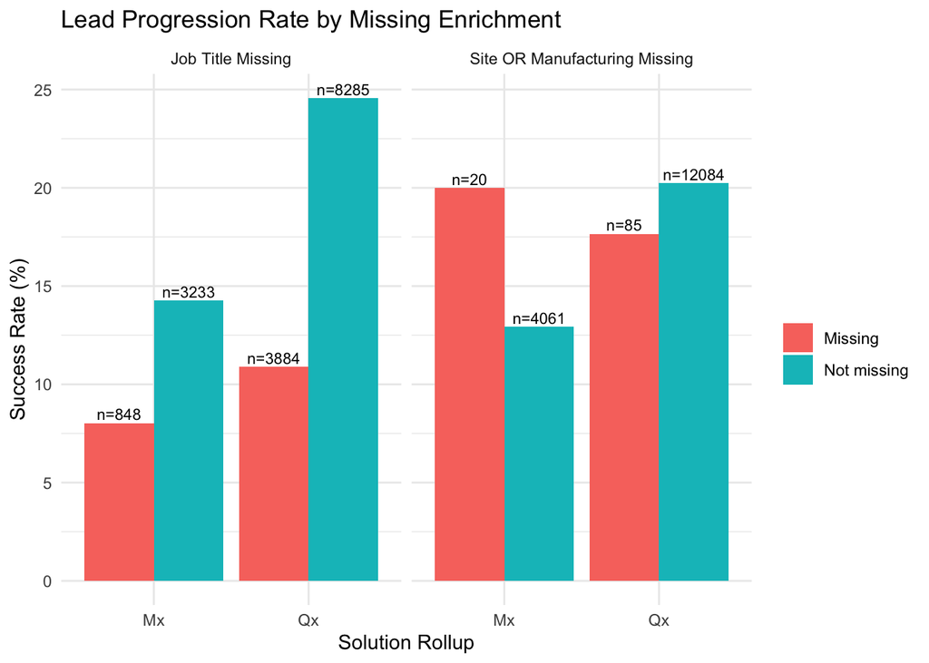

```r
ggplot(plot_df, aes(x = solution_rollup, y = success_rate, fill = missing_flag)) +
  geom_col(position = "dodge") +
  geom_text(aes(label = paste0("n=", n)),
            position = position_dodge(width = 0.9),
            vjust = -0.3, size = 3) +
  facet_wrap(~ missing_type) +
  labs(
    title = "Lead Progression Rate by Missing Enrichment",
    x = "Solution Rollup",
    y = "Success Rate (%)",
    fill = ""
  ) +
  theme_minimal()
```

##### Interpretation of Output

**Conclusion:** missingness is **not random** and should be kept as a **signal** (use missingness flags or explicit “Missing/Unknown” categories in modeling).

#### **Find a pattern with missing data**

##### MX Only: Where True Missingness Clusters

###### Composition of NA-Missing Leads by Channel, Tier, Territory, and Industry

In this section, we focus specifically on **MX leads** to understand whether missing enrichment fields follow a consistent pattern. We first restrict the data to records with a **known outcome** (`next_stage_c`) so success rates are comparable, then create a binary `success` indicator (SQL/SQO/Won = 1, otherwise = 0). Next, we define two missingness flags: `site_or_mfg_missing` (missing either site function or manufacturing model) and `title_missing` (missing job title).

Using these flags, we compare the composition of the missing vs not-missing groups across key categorical dimensions—**marketing channel**, **account tier**, **territory**, and **target industry**—by calculating within-group percentages. This helps identify where missingness is concentrated (e.g., specific channels or industries), and provides evidence that missing values may reflect systematic differences in lead source or profile rather than random data entry gaps.

```r
mx_miss <- leads %>%
  filter(!is.na(next_stage_c)) %>%
  mutate(success = if_else(next_stage_c %in% c("SQL","SQO","Won"), 1, 0)) %>%
  filter(solution_rollup == "Mx") %>%
  mutate(
    site_or_mfg_missing = is.na(acct_primary_site_function) | is.na(acct_manufacturing_model),
    title_missing = is.na(contact_lead_title)
  )

# Pattern: NA group mix by channel (top 10)
mx_miss %>%
  group_by(site_or_mfg_missing, last_tactic_campaign_channel) %>%
  summarise(n = n(), .groups="drop") %>%
  group_by(site_or_mfg_missing) %>%
  mutate(pct = round(100 * n / sum(n), 2)) %>%
  arrange(site_or_mfg_missing, desc(pct)) %>%
  slice_head(n = 10)
```

```
# A tibble: 17 × 4
# Groups:   site_or_mfg_missing [2]
   site_or_mfg_missing last_tactic_campaign_channel     n   pct
   <lgl>               <chr>                        <int> <dbl>
 1 FALSE               Email                         1097 27.0
 2 FALSE               External Demand Gen            933 23.0
 3 FALSE               Online Ads                     779 19.2
 4 FALSE               SEO                            454 11.2
 5 FALSE               Direct/Inbound                 324  7.98
 6 FALSE               Events                         186  4.58
 7 FALSE               Outbound Prospecting           106  2.61
 8 FALSE               Directory Listing              103  2.54
 9 FALSE               MISSING/BLANK                   36  0.89
10 FALSE               PR/AR/Social                    21  0.52
11 TRUE                Email                            7 35
12 TRUE                Online Ads                       6 30
13 TRUE                Directory Listing                2 10
14 TRUE                SEO                              2 10
15 TRUE                Events                           1  5
16 TRUE                External Demand Gen              1  5
17 TRUE                MISSING/BLANK                    1  5
```

```r
# Pattern: NA group mix by tier
mx_miss %>%
  group_by(site_or_mfg_missing, acct_tier_rollup) %>%
  summarise(n = n(), .groups="drop") %>%
  group_by(site_or_mfg_missing) %>%
  mutate(pct = round(100 * n / sum(n), 2)) %>%
  arrange(site_or_mfg_missing, desc(pct))
```

```
# A tibble: 9 × 4
# Groups:   site_or_mfg_missing [2]
  site_or_mfg_missing acct_tier_rollup     n   pct
  <lgl>               <chr>            <int> <dbl>
1 FALSE               Medium            2502 61.6
2 FALSE               Small              891 21.9
3 FALSE               Large              612 15.1
4 FALSE               Other               56  1.38
5 TRUE                <NA>                 9 45
6 TRUE                Medium               6 30
7 TRUE                Small                3 15
8 TRUE                Large                1  5
9 TRUE                Other                1  5
```

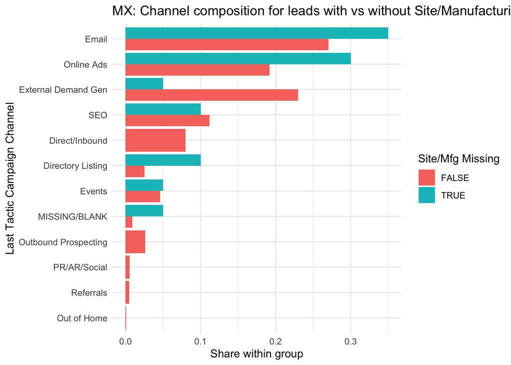

```r
# Visualization
mx_miss %>%
  group_by(site_or_mfg_missing, last_tactic_campaign_channel) %>%
  summarise(n = n(), .groups="drop") %>%
  group_by(site_or_mfg_missing) %>%
  mutate(pct = n / sum(n)) %>%
  ggplot(aes(x = reorder(last_tactic_campaign_channel, pct), y = pct, fill = site_or_mfg_missing)) +
  geom_col(position = "dodge") +
  coord_flip() +
  labs(
    title = "MX: Channel composition for leads with vs without Site/Manufacturing missing",
    x = "Last Tactic Campaign Channel",
    y = "Share within group",
    fill = "Site/Mfg Missing"
  ) +
  theme_minimal()
```

```r
#  Pattern: NA group mix by territory (MX)
mx_miss %>%
  group_by(site_or_mfg_missing, acct_territory_rollup) %>%
  summarise(n = n(), .groups="drop") %>%
  group_by(site_or_mfg_missing) %>%
  mutate(pct = round(100 * n / sum(n), 2)) %>%
  arrange(site_or_mfg_missing, desc(pct))
```

```
# A tibble: 11 × 4
# Groups:   site_or_mfg_missing [2]
   site_or_mfg_missing acct_territory_rollup     n   pct
   <lgl>               <chr>                 <int> <dbl>
 1 FALSE               Americas               2152 53.0
 2 FALSE               EMEA                    992 24.4
 3 FALSE               APAC & Oceania          867 21.4
 4 FALSE               Japan                    26  0.64
 5 FALSE               <NA>                     21  0.52
 6 FALSE               Unknown                   2  0.05
 7 FALSE               Antarctica                1  0.02
 8 TRUE                <NA>                      9 45
 9 TRUE                Americas                  5 25
10 TRUE                EMEA                      5 25
11 TRUE                APAC & Oceania            1  5
```

```r
# Pattern: NA group mix by target industry (MX) - top 10
mx_miss %>%
  group_by(site_or_mfg_missing, acct_target_industry) %>%
  summarise(n = n(), .groups="drop") %>%
  group_by(site_or_mfg_missing) %>%
  mutate(pct = round(100 * n / sum(n), 2)) %>%
  arrange(site_or_mfg_missing, desc(pct)) %>%
  slice_head(n = 10)
```

```
# A tibble: 9 × 4
# Groups:   site_or_mfg_missing [2]
  site_or_mfg_missing acct_target_industry     n   pct
  <lgl>               <chr>                <int> <dbl>
1 FALSE               Pharma & BioTech      1942 47.8
2 FALSE               Non-Life Science      1044 25.7
3 FALSE               Medical Device         922 22.7
4 FALSE               Blood & Biologics       94  2.31
5 FALSE               Unknown                 59  1.45
6 TRUE                <NA>                     9 45
7 TRUE                Non-Life Science         5 25
8 TRUE                Pharma & BioTech         5 25
9 TRUE                Unknown                  1  5
```

##### Interpretation of the Output (MX)

This matters because it means “missing” is telling us something about the lead itself and how it entered the system. In practice, missing enrichment can be treated like a warning sign that the lead may be lower quality or less well-qualified, or that the channel/source collects less complete information.

#### **MX Only: Where Low-Enrichment (“Low Info”) Clusters**

##### Composition of Low-Info Leads Using NA + Placeholder Values

In this section, we expand the definition of “missing” enrichment beyond true `NA` values. For two key fields—`acct_primary_site_function` and `acct_manufacturing_model`.We create a **Low Info** indicator that captures both:

- **True missing values (`NA`)**, and
- **Placeholder values** that represent incomplete enrichment (e.g., “Unknown”, “Not Enough Info Found”, “MISSING/BLANK”, or empty strings).

Then we focus only on MX leads with a known outcome, and we compare the composition of the Low Info group vs the not Low Info group across:

- marketing channel (last_tactic_campaign_channel)
- account tier (acct_tier_rollup)
- territory (acct_territory_rollup)
- target industry (acct_target_industry)

```r
mx_lowinfo <- leads %>%
  filter(!is.na(next_stage_c)) %>%
  mutate(success = if_else(next_stage_c %in% c("SQL","SQO","Won"), 1, 0)) %>%
  filter(solution_rollup == "Mx") %>%
  mutate(
    # define "low info" as NA OR placeholders
    site_lowinfo =
      is.na(acct_primary_site_function) |
      str_to_lower(str_trim(acct_primary_site_function)) %in% c("unknown", "not enough info found", "missing/blank", ""),
    mfg_lowinfo =
      is.na(acct_manufacturing_model) |
      str_to_lower(str_trim(acct_manufacturing_model)) %in% c("unknown", "not enough info found", "missing/blank", ""),
    site_or_mfg_lowinfo = site_lowinfo | mfg_lowinfo
  )

# 1) Channel mix
mx_lowinfo %>%
  group_by(site_or_mfg_lowinfo, last_tactic_campaign_channel) %>%
  summarise(n = n(), .groups="drop") %>%
  group_by(site_or_mfg_lowinfo) %>%
  mutate(pct = round(100 * n / sum(n), 2)) %>%
  arrange(site_or_mfg_lowinfo, desc(pct)) %>%
  slice_head(n = 10)
```

```
# A tibble: 20 × 4
# Groups:   site_or_mfg_lowinfo [2]
   site_or_mfg_lowinfo last_tactic_campaign_channel     n   pct
   <lgl>               <chr>                        <int> <dbl>
 1 FALSE               Email                          917 28.7
 2 FALSE               External Demand Gen            824 25.8
 3 FALSE               Online Ads                     551 17.3
 4 FALSE               SEO                            324 10.2
 5 FALSE               Direct/Inbound                 219  6.86
 6 FALSE               Events                         160  5.01
 7 FALSE               Outbound Prospecting            93  2.91
 8 FALSE               Directory Listing               46  1.44
 9 FALSE               MISSING/BLANK                   25  0.78
10 FALSE               Referrals                       16  0.5
11 TRUE                Online Ads                     234 26.4
12 TRUE                Email                          187 21.1
13 TRUE                SEO                            132 14.9
14 TRUE                External Demand Gen            110 12.4
15 TRUE                Direct/Inbound                 105 11.8
16 TRUE                Directory Listing               59  6.64
17 TRUE                Events                          27  3.04
18 TRUE                Outbound Prospecting            13  1.46
19 TRUE                MISSING/BLANK                   12  1.35
20 TRUE                PR/AR/Social                     6  0.68
```

```r
# 2) Tier mix
mx_lowinfo %>%
  group_by(site_or_mfg_lowinfo, acct_tier_rollup) %>%
  summarise(n = n(), .groups="drop") %>%
  group_by(site_or_mfg_lowinfo) %>%
  mutate(pct = round(100 * n / sum(n), 2)) %>%
  arrange(site_or_mfg_lowinfo, desc(pct))
```

```
# A tibble: 9 × 4
# Groups:   site_or_mfg_lowinfo [2]
  site_or_mfg_lowinfo acct_tier_rollup     n   pct
  <lgl>               <chr>            <int> <dbl>
1 FALSE               Medium            2033 63.7
2 FALSE               Small              641 20.1
3 FALSE               Large              478 15.0
4 FALSE               Other               41  1.28
5 TRUE                Medium             475 53.5
6 TRUE                Small              253 28.5
7 TRUE                Large              135 15.2
8 TRUE                Other               16  1.8
9 TRUE                <NA>                 9  1.01
```

```r
# 3) Territory mix
mx_lowinfo %>%
  group_by(site_or_mfg_lowinfo, acct_territory_rollup) %>%
  summarise(n = n(), .groups="drop") %>%
  group_by(site_or_mfg_lowinfo) %>%
  mutate(pct = round(100 * n / sum(n), 2)) %>%
  arrange(site_or_mfg_lowinfo, desc(pct))
```

```
# A tibble: 12 × 4
# Groups:   site_or_mfg_lowinfo [2]
   site_or_mfg_lowinfo acct_territory_rollup     n   pct
   <lgl>               <chr>                 <int> <dbl>
 1 FALSE               Americas               1647 51.6
 2 FALSE               EMEA                    787 24.6
 3 FALSE               APAC & Oceania          724 22.7
 4 FALSE               Japan                    22  0.69
 5 FALSE               <NA>                     13  0.41
 6 TRUE                Americas                510 57.4
 7 TRUE                EMEA                    210 23.6
 8 TRUE                APAC & Oceania          144 16.2
 9 TRUE                <NA>                     17  1.91
10 TRUE                Japan                     4  0.45
11 TRUE                Unknown                   2  0.23
12 TRUE                Antarctica                1  0.11
```

```r
# 4) Target industry mix (top 10)
mx_lowinfo %>%
  group_by(site_or_mfg_lowinfo, acct_target_industry) %>%
  summarise(n = n(), .groups="drop") %>%
  group_by(site_or_mfg_lowinfo) %>%
  mutate(pct = round(100 * n / sum(n), 2)) %>%
  arrange(site_or_mfg_lowinfo, desc(pct)) %>%
  slice_head(n = 10)
```

```
# A tibble: 11 × 4
# Groups:   site_or_mfg_lowinfo [2]
   site_or_mfg_lowinfo acct_target_industry     n   pct
   <lgl>               <chr>                <int> <dbl>
 1 FALSE               Pharma & BioTech      1683 52.7
 2 FALSE               Medical Device         754 23.6
 3 FALSE               Non-Life Science       628 19.7
 4 FALSE               Blood & Biologics       84  2.63
 5 FALSE               Unknown                 44  1.38
 6 TRUE                Non-Life Science       421 47.4
 7 TRUE                Pharma & BioTech       264 29.7
 8 TRUE                Medical Device         168 18.9
 9 TRUE                Unknown                 16  1.8
10 TRUE                Blood & Biologics       10  1.13
11 TRUE                <NA>                     9  1.01
```

#### Conclusion

Because these differences are large (especially by industry), we should not treat missing/placeholder values as random noise. Instead, we can keep a Low Info flag as a feature and/or combine missing/placeholder categories into a consistent Low Info level for modeling.

### Contact Lead Title - Additional Cleaning Steps

Before we do any in depth cleaning and standardization, we start by checking to see the number of unique and missing values for contact_lead_title field.

This field is free form entry, therefore this field has a huge variation in job titles. In future modeling, this will create additional noise and difficulty in interpretation.

```r
leads |>
  summarise(n = n(), n_unique = n_distinct(contact_lead_title),
            n_missing = sum(is.na(contact_lead_title) | contact_lead_title == ""))
```

```
# A tibble: 1 × 3
      n n_unique n_missing
  <int>    <int>     <int>
1 16644     6589      4861
```

**Unique Contact Lead Titles**

#### Pre-Processing Cleaning

Pre-processing steps are completed to reduce the number of unique values. This includes removing punctuation or special characters, numbers, errant spacing, converting to lower case and removing stop words.

```r
#remove special characters
leads <- leads |> mutate(
  contact_lead_title = contact_lead_title |>
    str_to_lower() |>
    str_replace_all("[^a-z\\s]", "") |>
    str_replace_all("\\s+", " ") |>
    str_trim()
)

stop_words_vec <- tidytext::stop_words$word

leads <- leads |>
  mutate(
    contact_lead_title = map_chr(
      contact_lead_title,
      ~ if (is.na(.x)) {
          NA_character_ #preserves NA values for now instead of turning to a string with value of NA
        } else {
          words <- str_split(.x, " ")[[1]]
          paste(words[!words %in% stop_words_vec], collapse = " ")
        }
    )
  )
```

```r
leads |>
  summarise(n = n(), n_unique = n_distinct(contact_lead_title),
            n_missing = sum(is.na(contact_lead_title) | contact_lead_title == ""))
```

```
# A tibble: 1 × 3
      n n_unique n_missing
  <int>    <int>     <int>
1 16644     6112      4914
```

#### Common Contact Title Groupings

To try and further reduce the number of unique values, AI was leveraged to come up with a map of common abbreviations and typing errors. This value map was then applied to the data, replacing the values where they occurred.

```r
title_map <- c(
  # --- common misspellings / normalization ---
  "cheif" = "chief",
  "chif" = "chief",
  "cheif executive officer" = "chief executive officer",
  "chief exec officer" = "chief executive officer",
  "chief exec" = "chief executive officer",
  "chief executive" = "chief executive officer",
  "chief operating" = "chief operating officer",
  "chief financial" = "chief financial officer",
  "chief technology" = "chief technology officer",
  "chief information" = "chief information officer",
  "chief marketing" = "chief marketing officer",
  "chief revenue" = "chief revenue officer",
  "chief product" = "chief product officer",
  "chief people" = "chief people officer",
  "chief customer" = "chief customer officer",
  "chief legal" = "chief legal officer",
  "chief compliance" = "chief compliance officer",
  "chief risk" = "chief risk officer",
  "chief security" = "chief security officer",
  "chief data" = "chief data officer",
  "chief analytics" = "chief analytics officer",

  "manger" = "manager",
  "mngr" = "manager",
  "managr" = "manager",
  "dirctor" = "director",
  "directer" = "director",
  "v p" = "vice president",
  "svp" = "senior vice president",
  "evp" = "executive vice president",
  "avp" = "assistant vice president",
  "vpres" = "vice president",
  "vice pres" = "vice president",
  "vice-president" = "vice president",

  "asst" = "assistant",
  "assitant" = "assistant",
  "assisstant" = "assistant",
  "assoc" = "associate",
  "assc" = "associate",
  "sr" = "senior",
  "s r" = "senior",
  "snr" = "senior",
  "senr" = "senior",
  "jr" = "junior",
  "j r" = "junior",
  "jnr" = "junior",
  "lead" = "lead",
  "principal" = "principal",
  "prinicipal" = "principal",
  "pricipal" = "principal",
  "staff" = "staff",
  "intern" = "intern",
  "trainee" = "trainee",
  "apprentice" = "apprentice",

  # --- founders / ownership ---
  "co founder" = "cofounder",
  "co-founder" = "cofounder",
  "cofounder" = "cofounder",
  "founder" = "founder",
  "owner" = "owner",
  "proprietor" = "owner",
  "partner" = "partner",
  "managing partner" = "managing partner",

  # --- C-suite acronyms (expand) ---
  "ceo" = "chief executive officer",
  "coo" = "chief operating officer",
  "cfo" = "chief financial officer",
  "cto" = "chief technology officer",
  "cio" = "chief information officer",
  "cmo" = "chief marketing officer",
  "cro" = "chief revenue officer",
  "cpo" = "chief product officer",
  "cdo" = "chief data officer",              # sometimes "chief digital officer"—watch ambiguity
  "cso" = "chief security officer",          # sometimes "chief strategy officer"—watch ambiguity
  "chro" = "chief human resources officer",
  "clo" = "chief legal officer",
  "cco" = "chief compliance officer",        # sometimes "chief commercial officer"—watch ambiguity
  "ciso" = "chief information security officer",
  "cbo" = "chief business officer",
  "cxo" = "chief executive officer",

  # --- senior leadership / exec roles ---
  "pres" = "president",
  "president" = "president",
  "vice president" = "vice president",
  "senior vice president" = "senior vice president",
  "executive vice president" = "executive vice president",
  "managing director" = "managing director",
  "md" = "managing director",                # ambiguous in healthcare
  "gm" = "general manager",                  # ambiguous but common
  "general mgr" = "general manager",

  # --- management / leadership ---
  "dir" = "director",
  "director" = "director",
  "sr director" = "senior director",
  "senior director" = "senior director",
  "exec director" = "executive director",
  "executive director" = "executive director",

  "mgr" = "manager",
  "manager" = "manager",
  "sr mgr" = "senior manager",
  "senior manager" = "senior manager",
  "asst manager" = "assistant manager",
  "assistant manager" = "assistant manager",

  "supervisor" = "supervisor",
  "team lead" = "team lead",
  "tl" = "team lead",                        # can be noisy—watch ambiguity

  # --- functional common abbreviations ---
  "hr" = "human resources",
  "it" = "information technology",
  "pr" = "public relations",
  "qa" = "quality assurance",
  "qc" = "quality control",
  "ops" = "operations",
  "biz dev" = "business development",
  "bd" = "business development",             # ambiguous (can be “board” in some contexts)
  "sales rep" = "sales representative",
  "rep" = "representative",
  "sr rep" = "senior representative",

  # --- engineering / tech ---
  "swe" = "software engineer",
  "sdet" = "software development engineer in test",
  "devops" = "devops",
  "dev ops" = "devops",
  "secops" = "security operations",
  "data sci" = "data scientist",
  "ds" = "data scientist",                   # ambiguous
  "ml" = "machine learning",
  "ai" = "artificial intelligence",

  # --- product / project (high ambiguity) ---
  "pm" = "project manager",                  # could be product manager
  "pmo" = "project management office",
  "po" = "product owner",
  "scrum master" = "scrum master",

  # --- finance / accounting ---
  "acct" = "accountant",
  "accounting" = "accounting",
  "fp a" = "financial planning and analysis",
  "fpa" = "financial planning and analysis",
  "ap" = "accounts payable",
  "ar" = "accounts receivable",
  "cpa" = "certified public accountant",

  # --- legal / compliance / risk ---
  "gc" = "general counsel",
  "counsel" = "counsel",
  "attorney" = "attorney",
  "compliance" = "compliance",
  "risk" = "risk",
  "audit" = "audit",

  # --- customer / service / success ---
  "cs" = "customer success",                 # ambiguous (computer science)
  "csr" = "customer service representative",
  "support" = "support",
  "customer support" = "customer support",

  # --- misc common role words ---
  "admin" = "administrator",
  "administrator" = "administrator",
  "assistant" = "assistant",
  "coordinator" = "coordinator",
  "specialist" = "specialist",
  "analyst" = "analyst",
  "consultant" = "consultant",
  "engineer" = "engineer",
  "developer" = "developer"
)
```

```r
replace_word <- function(x, from, to) {
  str_replace_all(x, regex(paste0("\\b", from, "\\b"), ignore_case = TRUE), to)
}
```

```r
leads <- leads |>
  mutate(
    contact_lead_title = reduce(
      names(title_map),
      .init = contact_lead_title,
      .f = \(acc, k) replace_word(acc, k, title_map[[k]])
    ) |>
      str_replace_all("\\s+", " ") |>
      str_trim()
  )
```

```r
leads |>
  summarise(n = n(), n_unique = n_distinct(contact_lead_title),
            n_missing = sum(is.na(contact_lead_title) | contact_lead_title == ""))
```

```
# A tibble: 1 × 3
      n n_unique n_missing
  <int>    <int>     <int>
1 16644     6006      4914
```

**Contact Lead Title Grouping Output**

This further reduces the unique values down by another ~100 values. The problem at this step is that there are varying combinations of common words that can occur in different frequencies.

#### Contact Lead Title Word Cloud

If we look at a word cloud of the most common 50 words, there is no surprise at what shows up the most frequently.

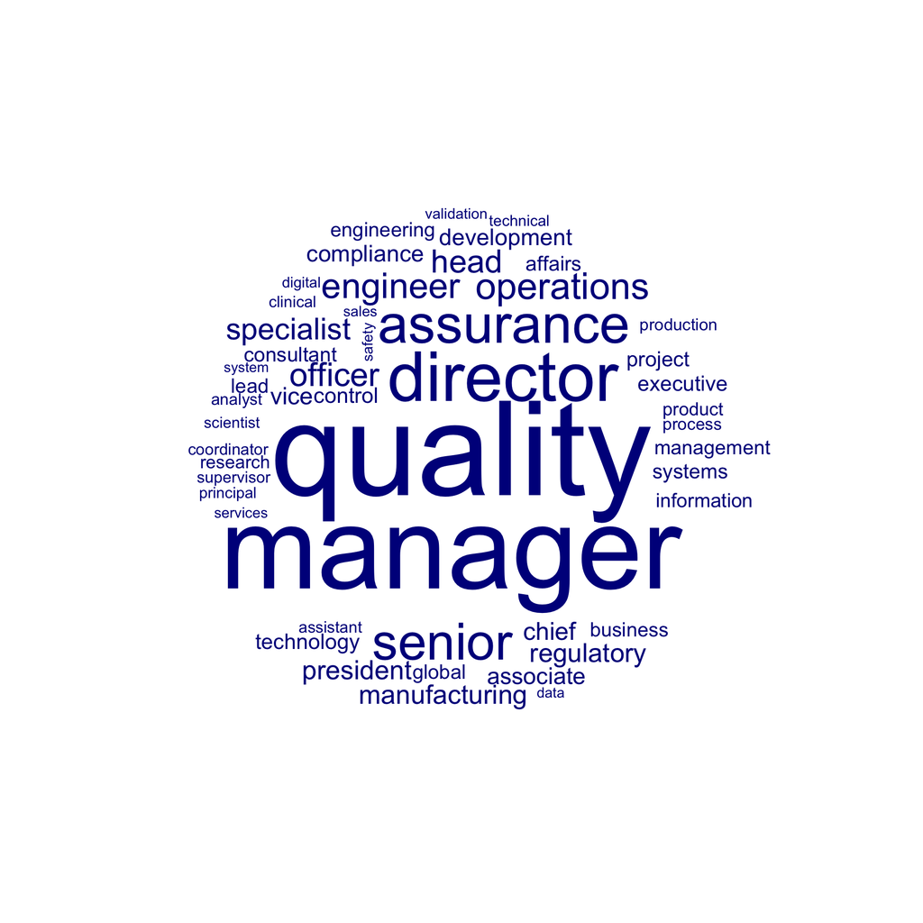

```r
#remove whitespace
par(mar = c(0,0,0,0), oma = c(0,0,0,0), xaxs = "i", yaxs = "i")

corp <- corpus(leads, text_field = "contact_lead_title")
toks <- tokens(corp)
dfm_mat <- dfm(toks)

textplot_wordcloud(dfm_mat, max_words = 50, max_size = 6, min_size = 0.5)
```

**Word Cloud Output** Manager, quality, director, assurance, and senior are the most common words implicated by the word cloud.

#### Most Common Word Data Frame

To account for the various combination of words, a data frame is created of the most common occurring words. Only words that occur at least 5 times are retained. These words will be used to create a flag variable if that word occurred or not.

```r
top_features <- topfeatures(dfm_mat,10000)

top_features_df <- data.frame(
  feature = names(top_features),
  count = as.numeric(top_features))

count(top_features_df)
```

```
     n
1 2385
```

```r
non_blank <- leads |>
  summarise(n = n() - sum(is.na(contact_lead_title) | contact_lead_title == "")) |>
  pull(n)

top_features_df <- top_features_df |> filter(count >= 5)
top_features_df <- top_features_df |> mutate(percentage_occured_non_blank = count / non_blank)
head(top_features_df,10)
```

```
      feature count percentage_occured_non_blank
1     quality  3953                   0.33699915
2     manager  3464                   0.29531117
3    director  1903                   0.16223359
4   assurance  1426                   0.12156863
5      senior  1325                   0.11295823
6  operations   860                   0.07331628
7    engineer   805                   0.06862745
8     officer   720                   0.06138107
9        head   697                   0.05942029
10 specialist   631                   0.05379369
```

```r
tail(top_features_df,10)
```

```
      feature count percentage_occured_non_blank
395     brand     5                 0.0004262575
396      lean     5                 0.0004262575
397      user     5                 0.0004262575
398    energy     5                 0.0004262575
399 sterility     5                 0.0004262575
400 certified     5                 0.0004262575
401     trial     5                 0.0004262575
402   capital     5                 0.0004262575
403      west     5                 0.0004262575
404     dscsa     5                 0.0004262575
```

**Common Words Data Frame Output**

We can see from below that ~34% of titles have “quality”, and ~30% have manager.

#### Common Words Bi-Grams

Additionally we can look at just bi-grams (sequences of only two words from the title field), if we look at this it does give us some more information in regards to word order. However, the number of unique word combinations then goes back up greatly, so this will not be further evaluated.

```r
toks_bigram <-tokens_ngrams(toks,n = 2)
dfm_bigram <-dfm(toks_bigram)

top_features_bi <- topfeatures(dfm_bigram,10000)

top_features_df_bi <- data.frame(
  feature = names(top_features_bi),
  count = as.numeric(top_features_bi))

count(top_features_df_bi)
```

```
     n
1 7617
```

```r
top_features_df_bi <- top_features_df_bi |> filter(count >= 5)
top_features_df_bi <- top_features_df_bi |> mutate(percentage_occured_non_blank = count / non_blank)
head(top_features_df_bi,10)
```

```
                  feature count percentage_occured_non_blank
1       quality_assurance  1395                   0.11892583
2         manager_quality   597                   0.05089514
3        director_quality   423                   0.03606138
4          vice_president   420                   0.03580563
5         quality_manager   347                   0.02958227
6          senior_manager   313                   0.02668372
7      regulatory_affairs   291                   0.02480818
8         quality_control   263                   0.02242114
9       assurance_manager   240                   0.02046036
10 information_technology   211                   0.01798806
```

### Clean Dataset

In this section, we create a cleaned version of the leads dataset that we can use for EDA (and later modeling) without removing rows.

#### **Steps:**

- Keep all original columns
- Standardize “missing-like” text in categorical fields by converting blanks and placeholder values (e.g., “Unknown”, “Not Enough Info Found”, “MISSING/BLANK”) into true NA.
- Use a recipes pipeline to replace NA values in categorical predictor columns only with a consistent category level called “Low Info” so incomplete enrichment is explicit and rows are retained.
- Create indicator flags (site_lowinfo, mfg_lowinfo, title_lowinfo, site_or_mfg_lowinfo) that capture whether key enrichment fields ended up as “Low Info”.
- We **do not modify** `next_stage_c` in the recipe because it represents the outcome; any missing outcomes remain missing and are handled separately when computing success rates.

```r
# Drop rows with missing target/outcome
leads_model <- leads %>%
  filter(!is.na(next_stage_c))

# Convert placeholder text + blanks to NA (for character/factor columns)
to_na_lowinfo <- function(x) {
  x <- str_trim(x)
  x <- na_if(x, "")
  x <- if_else(
    str_to_lower(x) %in% c("missing/blank", "unknown", "not enough info found"),
    NA_character_,
    x
  )
  x
}

rec_clean_only <- recipe(~ ., data = leads_model) %>%
  # Keep IDs as-is (do not clean/encode them as predictors)
  update_role(qal_id, contact_lead_id, new_role = "id") %>%

  # Keep outcome column as-is (do not clean it as a predictor)
  update_role(next_stage_c, new_role = "outcome") %>%

  # Clean categorical predictors ONLY (excludes id + outcome roles)
  step_mutate_at(all_nominal_predictors(), fn = to_na_lowinfo) %>%

  # Replace NA in categorical predictors with a consistent level
  step_unknown(all_nominal_predictors(), new_level = "Low Info") %>%

  # Create flags AFTER "Low Info" exists
  step_mutate(
    site_lowinfo        = acct_primary_site_function == "Low Info",
    mfg_lowinfo         = acct_manufacturing_model   == "Low Info",
    title_lowinfo       = contact_lead_title         == "Low Info",
    site_or_mfg_lowinfo = site_lowinfo | mfg_lowinfo
  )

# Apply recipe
prep_clean_only <- prep(rec_clean_only, training = leads_model, retain = TRUE)
leads_cleaned_only <- bake(prep_clean_only, new_data = NULL)

# Quick checks
dim(leads)
```

```
[1] 16644    14
```

```r
dim(leads_cleaned_only)
```

```
[1] 16250    18
```

```r
colSums(is.na(leads_cleaned_only))
```

```
  acct_primary_site_function     acct_manufacturing_model
                           0                            0
        acct_target_industry           contact_lead_title
                           0                            0
                      qal_id              contact_lead_id
                           0                            2
                next_stage_c                     priority
                           0                            0
       acct_territory_rollup             acct_tier_rollup
                           0                            0
                    solution              solution_rollup
                           0                            0
last_tactic_campaign_channel              qal_cohort_date
                           0                            0
                site_lowinfo                  mfg_lowinfo
                           0                            0
               title_lowinfo          site_or_mfg_lowinfo
                           0                            0
```

```r
table(leads_cleaned_only$site_or_mfg_lowinfo, useNA = "ifany")
```

```
FALSE  TRUE
11569  4681
```

- Once the recipe has done the data cleaning the last step is merging the one hot encoded data back to the main cleaned data frame.

```r
#change from factor before creating corpus/tokens
leads_cleaned_only <- leads_cleaned_only %>%
  mutate(contact_lead_title = as.character(contact_lead_title))

#create corpus and tokens
corp <- corpus(
  leads_cleaned_only,
  text_field = "contact_lead_title")

toks <- tokens(corp)

toks_onehot <- tokens_select(
  toks,
  pattern = top_features_df$feature)

#create one hot encoded matrix
dfm_onehot <- dfm(toks_onehot)
dfm_onehot_bin <- dfm_weight(dfm_onehot, scheme = "boolean")
df_encoded <- convert(dfm_onehot_bin, to = "data.frame")

#join back together
leads_cleaned_only <-cbind(leads_cleaned_only, df_encoded[,-1])

#check duplicated columns for target variable binary conversion
colnames(leads_cleaned_only)[duplicated(colnames(leads_cleaned_only))]
```

```
[1] "solution"
```

```r
dup_cols <- colnames(leads_cleaned_only)[colnames(leads_cleaned_only) %in% colnames(leads_cleaned_only)[duplicated(colnames(leads_cleaned_only))]]
dup_cols
```

```
[1] "solution" "solution"
```

```r
#view duplicate columns
#leads_cleaned_only[, dup_cols]

#drop solution.1
leads_cleaned_final <- leads_cleaned_only[, colnames(leads_cleaned_only) != "solution.1"]
head(leads_cleaned_final)
```

```
      acct_primary_site_function           acct_manufacturing_model
1              Food and beverage            Consumer Packaged Goods
2           Surgical instruments                           In-House
3     Cell therapies (CAR-T, NK) Hospital Investigational Drug Unit
4 In-vitro diagnostic (IVD) kits                           In-House
5    Nutraceutical manufacturing                                CMO
6           Diagnostic Equipment                           In-House
  acct_target_industry             contact_lead_title             qal_id
1     Non-Life Science      quality assurance manager a0dPQ000005WbfuYAC
2       Medical Device                quality manager a0dPQ00000CRpkLYAT
3    Blood & Biologics                            ing a0dPQ000000KWdFYAW
4       Medical Device                senior director a0dPQ000004LOWTYA4
5     Pharma & BioTech senior manager quality systems a0dPQ000000BrKLYA0
6       Medical Device    document control specialist a0dPQ000000g4aHYAQ
     contact_lead_id next_stage_c          priority acct_territory_rollup
```

[output cut: 363 more lines]

```r
#check for duplicates again
colnames(leads_cleaned_final)[duplicated(colnames(leads_cleaned_final))]
```

```
character(0)
```

```r
#now convert target to binary
leads_cleaned_final <- leads_cleaned_final %>%
  mutate(
    next_stage_target = factor(
      if_else(next_stage_c %in% c("SQL", "SQO", "Won"), 1, 0)
    )
  )

#view dataframe
head(leads_cleaned_final)
```

```
      acct_primary_site_function           acct_manufacturing_model
1              Food and beverage            Consumer Packaged Goods
2           Surgical instruments                           In-House
3     Cell therapies (CAR-T, NK) Hospital Investigational Drug Unit
4 In-vitro diagnostic (IVD) kits                           In-House
5    Nutraceutical manufacturing                                CMO
6           Diagnostic Equipment                           In-House
  acct_target_industry             contact_lead_title             qal_id
1     Non-Life Science      quality assurance manager a0dPQ000005WbfuYAC
2       Medical Device                quality manager a0dPQ00000CRpkLYAT
3    Blood & Biologics                            ing a0dPQ000000KWdFYAW
4       Medical Device                senior director a0dPQ000004LOWTYA4
5     Pharma & BioTech senior manager quality systems a0dPQ000000BrKLYA0
6       Medical Device    document control specialist a0dPQ000000g4aHYAQ
     contact_lead_id next_stage_c          priority acct_territory_rollup
```

[output cut: 363 more lines]

```r
#save final modeling-ready dataset
dir.create("data", showWarnings = FALSE)
saveRDS(leads_cleaned_final, "data/leads_cleaned_final.rds")
```

#### Interpretation (Clean Dataset checks)

**Key takeaway:** After restricting to leads with known outcomes, low-enrichment (**“Low Info”**) values remain very common and should be treated as signal rather than noise. We standardize missing/placeholder values into a consistent **“Low Info”** category for categorical predictors and create indicator flags (e.g., `site_or_mfg_lowinfo`, `title_lowinfo`) so downstream models can learn the relationship between enrichment quality and lead progression.

# Clustering EDA

Clustering reveals multi-dimensional lead segments that simple cross-tabulations cannot surface. Where a bar chart shows one variable at a time (e.g., industry vs. conversion), clustering operates across all dimensions simultaneously — discovering combinations like “Small tier + EMEA + Medical Device + SEO channel” that form coherent, high-converting archetypes invisible in univariate analysis.

### Shared Setup: Create Success Variable and Site Function Groupings

```r
# Set up cache directory for expensive clustering computations
cache_dir <- "EDA-Master-Control_cache/clustering"
dir.create(cache_dir, recursive = TRUE, showWarnings = FALSE)

# Fix duplicate column names from cbind() of one-hot encoded title words
# (cbind can produce duplicates if any title word matches an existing column)
dup_cols <- duplicated(names(leads_cleaned_only))
if (any(dup_cols)) {
  cat("Removing", sum(dup_cols), "duplicate columns\n")
  leads_cleaned_only <- leads_cleaned_only[, !dup_cols]
}
```

```
Removing 1 duplicate columns
```

```r
# Create binary success variable on the cleaned dataset
leads_clustered <- leads_cleaned_only %>%
  mutate(
    success = if_else(next_stage_c %in% c("SQL", "SQO", "Won"), 1, 0),
    # Group 78+ site function levels into 5 categories
    # (based on case_description.txt suggested groupings)
    site_function_group = case_when(
      acct_primary_site_function %in% c(
        "Oral solid dosage (OSD)", "Sterile injectables",
        "Small-molecule API", "Biologic API",
        "Cell therapies (CAR-T, NK)", "Generics manufacturing",
        "Drug discovery & development", "Nutraceutical manufacturing"
      ) ~ "Active Pharma Mfg",
      acct_primary_site_function %in% c(
        "Implantable devices", "In-vitro diagnostic (IVD) kits",
        "Diagnostic Equipment", "Surgical instruments",
        "Single-use disposables"
      ) ~ "Med Device Mfg",
      acct_primary_site_function %in% c(
        "Non-manufacturing organization", "Low Info"
      ) ~ "Non-Mfg / Low Info",
      acct_primary_site_function %in% c(
        "Food and beverage", "Cosmetics manufacturing",
        "Specialty Chemical Manufacturing", "Secondary packaging",
        "Lab Instruments"
      ) ~ "Other Mfg",
      TRUE ~ "Other Mfg"
    ),
    site_function_group = factor(site_function_group)
  )
```

## Analysis 1: Account Profile Clustering (Gower + PAM)

We cluster all leads on account-level categorical features to discover natural account archetypes. PAM (Partitioning Around Medoids) with Gower distance is ideal for purely categorical data — medoids are real data points, making clusters directly interpretable.

### Prepare Features

```r
acct_df <- leads_clustered %>%
  select(acct_target_industry, acct_manufacturing_model,
         site_function_group, acct_tier_rollup,
         acct_territory_rollup, site_or_mfg_lowinfo) %>%
  mutate(across(everything(), as.factor))

dim(acct_df)
```

```
[1] 16250     6
```

### Compute Gower Distance and Optimal k

```r
set.seed(42)

cache_file <- file.path(cache_dir, "gower_acct.rds")
if (file.exists(cache_file)) {
  cached <- readRDS(cache_file)
  gower_dist <- cached$gower_dist
  sil_widths <- cached$sil_widths
  cat("Loaded gower_dist and sil_widths from cache\n")
} else {
  # Gower distance handles mixed/categorical data natively
  gower_dist <- daisy(acct_df, metric = "gower")

  # Search for optimal k via silhouette width
  sil_widths <- sapply(2:10, function(k) {
    pam_fit <- pam(gower_dist, k = k, diss = TRUE)
    pam_fit$silinfo$avg.width
  })

  saveRDS(list(gower_dist = gower_dist, sil_widths = sil_widths), cache_file)
  cat("Computed and cached gower_dist and sil_widths\n")
}
```

```
Loaded gower_dist and sil_widths from cache
```

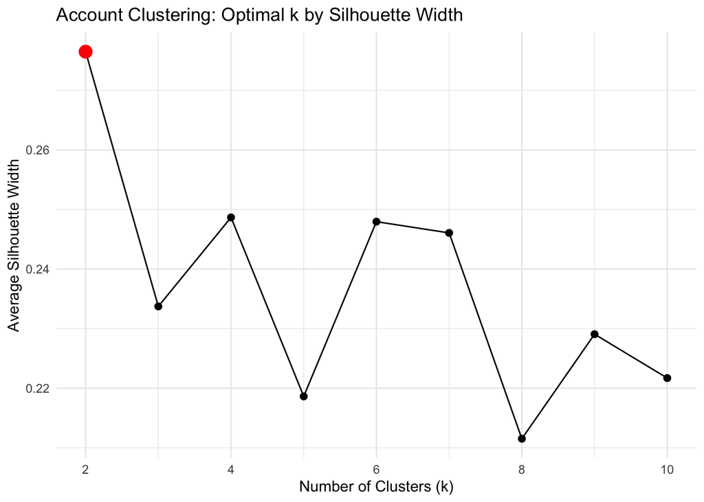

```r
sil_df <- data.frame(k = 2:10, avg_silhouette = sil_widths)

ggplot(sil_df, aes(x = k, y = avg_silhouette)) +
  geom_line() +
  geom_point(size = 2) +
  geom_point(data = sil_df %>% filter(avg_silhouette == max(avg_silhouette)),
             color = "red", size = 4) +
  labs(title = "Account Clustering: Optimal k by Silhouette Width",
       x = "Number of Clusters (k)", y = "Average Silhouette Width") +
  theme_minimal()
```

```r
best_k_acct <- sil_df$k[which.max(sil_df$avg_silhouette)]
cat("Optimal k:", best_k_acct, "with avg silhouette:", max(sil_df$avg_silhouette))
```

```
Optimal k: 2 with avg silhouette: 0.2764791
```

### Fit Final PAM Model

```r
cache_file <- file.path(cache_dir, "pam_acct.rds")
if (file.exists(cache_file)) {
  pam_acct <- readRDS(cache_file)
  cat("Loaded pam_acct from cache\n")
} else {
  pam_acct <- pam(gower_dist, k = best_k_acct, diss = TRUE)
  saveRDS(pam_acct, cache_file)
  cat("Computed and cached pam_acct\n")
}
```

```
Loaded pam_acct from cache
```

```
  cluster  size ave.sil.width
1       1 10048          0.25
2       2  6202          0.32
```

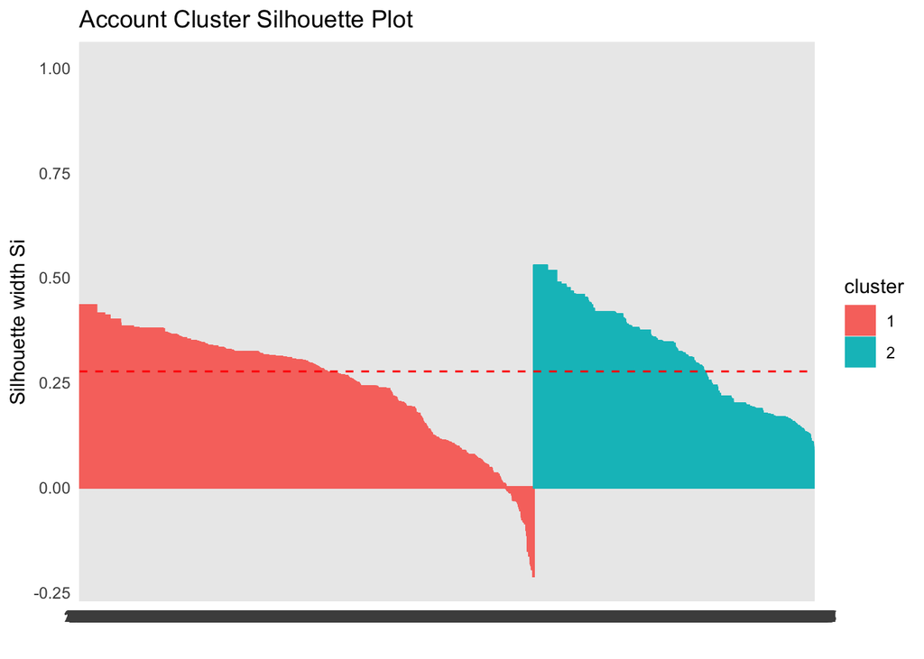

```r
# Append cluster labels
leads_clustered$account_cluster <- factor(pam_acct$clustering)

# Silhouette plot
fviz_silhouette(pam_acct) +
  labs(title = "Account Cluster Silhouette Plot") +
  theme_minimal()
```

### MCA Biplot with Cluster Overlay

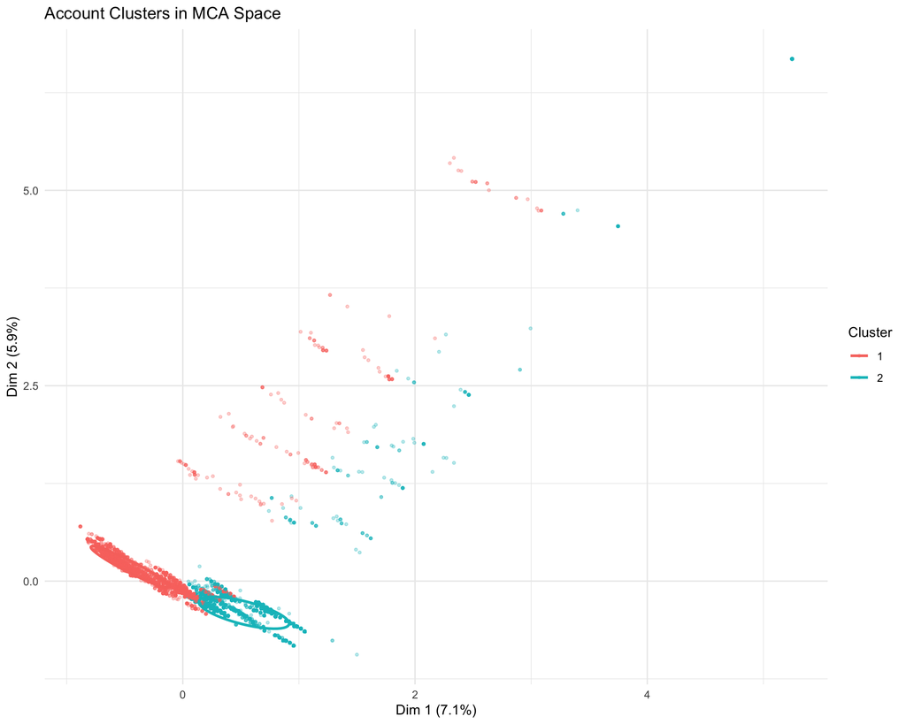

```r
# MCA is the categorical analogue of PCA
mca_acct <- MCA(acct_df, graph = FALSE)

# Extract individual coordinates and color by cluster
mca_ind <- data.frame(mca_acct$ind$coord[, 1:2])
mca_ind$cluster <- leads_clustered$account_cluster

ggplot(mca_ind, aes(x = Dim.1, y = Dim.2, color = cluster)) +
  geom_point(alpha = 0.3, size = 0.8) +
  stat_ellipse(level = 0.7, linewidth = 1) +
  labs(title = "Account Clusters in MCA Space",
       x = paste0("Dim 1 (", round(mca_acct$eig[1, 2], 1), "%)"),
       y = paste0("Dim 2 (", round(mca_acct$eig[2, 2], 1), "%)"),
       color = "Cluster") +
  theme_minimal()
```

Multi Correspondence Analysis: reduces categorical variables into a 2 dimensional space. Each point on the plot is an account/lead. Their position is based on similar features like industry, manufacturing type, etc. The colors/groups are the cluster assignments. - The leads that appear close together share similar characteristics, while the leads that are far apart are more different. As shown, Cluster 1 appears more closely together than Cluster 2, where Cluster 1 has a clear focused grouping, while Cluster 2 is more mixed. Cluster 2 across the MCA space is more spread out, had less similar characteristics and wide variety of regions, company types, or incomplete information.

**Key Takeaways:**

- There is structure to the data
- There is one strong, cohesive lead segment
- Another grouping is broader and less well-defined

### Cluster Composition Heatmap

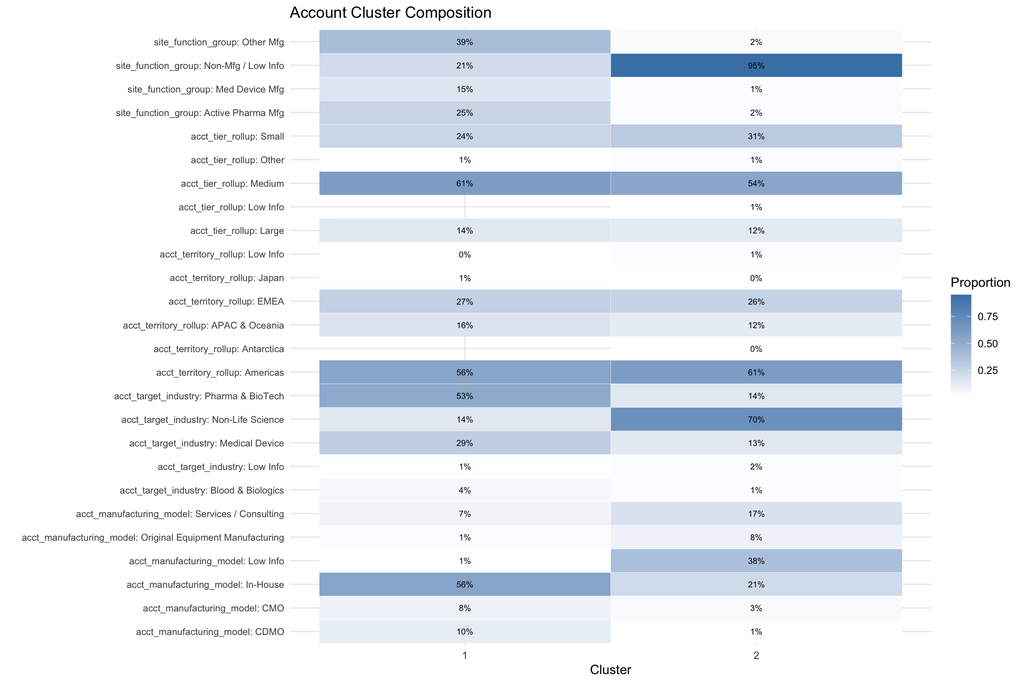

```r
# Calculate proportion of each category level within each cluster
comp_long <- leads_clustered %>%
  select(account_cluster, acct_target_industry, acct_manufacturing_model,
         site_function_group, acct_tier_rollup, acct_territory_rollup) %>%
  pivot_longer(-account_cluster, names_to = "variable", values_to = "level") %>%
  count(account_cluster, variable, level) %>%
  group_by(account_cluster, variable) %>%
  mutate(prop = n / sum(n)) %>%
  ungroup()

# Show top levels per variable for readability
top_levels <- comp_long %>%
  group_by(variable, level) %>%
  summarise(total_n = sum(n), .groups = "drop") %>%
  group_by(variable) %>%
  slice_max(total_n, n = 6) %>%
  pull(level)

comp_filtered <- comp_long %>%
  filter(level %in% top_levels) %>%
  mutate(label = paste0(variable, ": ", level))

ggplot(comp_filtered, aes(x = account_cluster, y = label, fill = prop)) +
  geom_tile(color = "white") +
  geom_text(aes(label = scales::percent(prop, accuracy = 1)), size = 2.5) +
  scale_fill_gradient(low = "white", high = "steelblue") +
  labs(title = "Account Cluster Composition",
       x = "Cluster", y = "", fill = "Proportion") +
  theme_minimal() +
  theme(axis.text.y = element_text(size = 8))
```

### Conversion Rate by Account Cluster

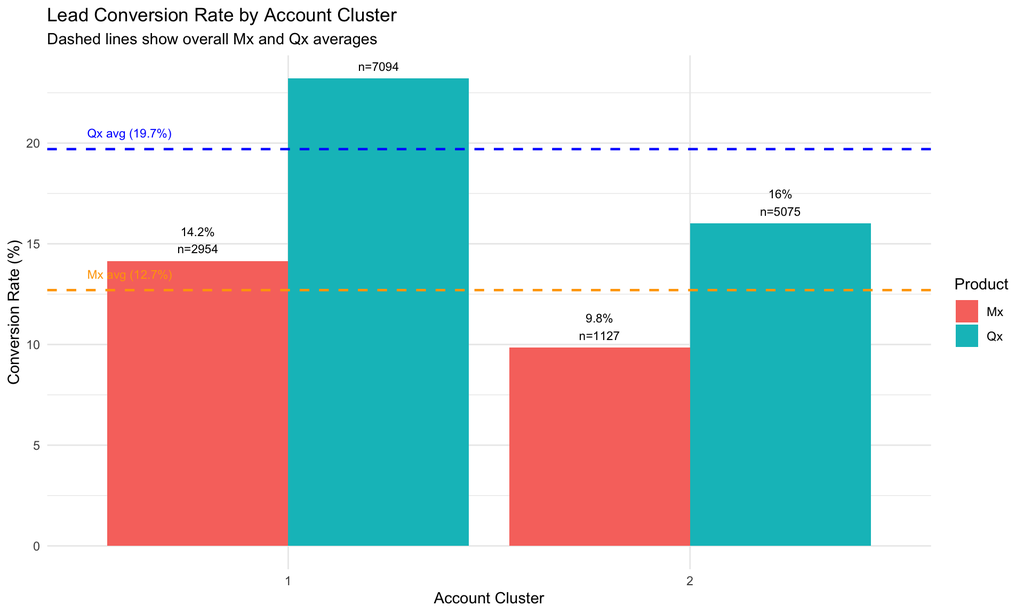

```r
acct_conv <- leads_clustered %>%
  group_by(account_cluster, solution_rollup) %>%
  summarise(
    n = n(),
    conversion = mean(success) * 100,
    .groups = "drop"
  )

ggplot(acct_conv, aes(x = account_cluster, y = conversion, fill = solution_rollup)) +
  geom_col(position = "dodge") +
  geom_text(aes(label = paste0(round(conversion, 1), "%\nn=", n)),
            position = position_dodge(width = 0.9), vjust = -0.3, size = 3) +
  geom_hline(yintercept = 12.7, linetype = "dashed", color = "orange", linewidth = 0.8) +
  geom_hline(yintercept = 19.7, linetype = "dashed", color = "blue", linewidth = 0.8) +
  annotate("text", x = 0.5, y = 13.5, label = "Mx avg (12.7%)", color = "orange", hjust = 0, size = 3) +
  annotate("text", x = 0.5, y = 20.5, label = "Qx avg (19.7%)", color = "blue", hjust = 0, size = 3) +
  labs(title = "Lead Conversion Rate by Account Cluster",
       subtitle = "Dashed lines show overall Mx and Qx averages",
       x = "Account Cluster", y = "Conversion Rate (%)", fill = "Product") +
  theme_minimal()
```

### Cluster Size Summary

```r
cluster_summary <- leads_clustered %>%
  group_by(account_cluster) %>%
  summarise(
    n = n(),
    pct_of_total = round(100 * n() / nrow(leads_clustered), 1),
    mx_conversion = round(mean(success[solution_rollup == "Mx"]) * 100, 2),
    qx_conversion = round(mean(success[solution_rollup == "Qx"]) * 100, 2),
    pct_lowinfo = round(mean(site_or_mfg_lowinfo == TRUE) * 100, 1),
    .groups = "drop"
  )

cluster_summary
```

```
# A tibble: 2 × 6
  account_cluster     n pct_of_total mx_conversion qx_conversion pct_lowinfo
  <fct>           <int>        <dbl>         <dbl>         <dbl>       <dbl>
1 1               10048         61.8         14.2           23.2         2.3
2 2                6202         38.2          9.85          16.0        71.7
```

### Medoid Profiles (Cluster Archetypes)

```r
# The medoid is the most representative lead in each cluster
medoid_rows <- pam_acct$id.med
medoid_profiles <- leads_clustered[medoid_rows, ] %>%
  select(account_cluster, acct_target_industry, acct_manufacturing_model,
         site_function_group, acct_tier_rollup, acct_territory_rollup,
         site_or_mfg_lowinfo)

medoid_profiles
```

```
      account_cluster acct_target_industry acct_manufacturing_model
30                  1     Pharma & BioTech                 In-House
16192               2     Non-Life Science                 Low Info
      site_function_group acct_tier_rollup acct_territory_rollup
30              Other Mfg           Medium              Americas
16192  Non-Mfg / Low Info           Medium              Americas
      site_or_mfg_lowinfo
30                  FALSE
16192                TRUE
```

#### Business Translation

Each cluster represents a distinct account archetype. Compare the conversion rates above to the MX baseline of **12.7%**. Clusters with above-average conversion contain the account profiles that show a strong signal for MX targeting. Clusters with very low conversion (especially those dominated by “Low Info” or “Non-Mfg”) represent targeting waste.

## Analysis 2: Title-Based Role Clustering (Jaccard + Hierarchical)

### Prepare Title Data

```r
# Identify title word indicator columns (binary flags from one-hot encoding)
title_word_cols <- top_features_df$feature

# Filter to rows with actual titles (not Low Info)
title_df <- leads_clustered %>%
  filter(title_lowinfo == FALSE) %>%
  select(all_of(title_word_cols))

# Convert to numeric matrix for distance computation
title_mat <- as.matrix(title_df)
storage.mode(title_mat) <- "integer"

cat("Title matrix dimensions:", dim(title_mat), "\n")
```

```
Title matrix dimensions: 11485 404
```

```r
cat("Rows with titles:", nrow(title_mat))
```

```
Rows with titles: 11485
```

### Compute Jaccard Distance and Hierarchical Clustering

```r
set.seed(42)

cache_file <- file.path(cache_dir, "jacc_title.rds")
if (file.exists(cache_file)) {
  cached <- readRDS(cache_file)
  jacc_dist <- cached$jacc_dist
  hc_title <- cached$hc_title
  sample_idx <- cached$sample_idx
  title_mat_sample <- title_mat[sample_idx, ]
  cat("Loaded jacc_dist, hc_title, and sample_idx from cache\n")
} else {
  # If dataset is large, sample for distance computation
  if (nrow(title_mat) > 5000) {
    sample_idx <- sample(nrow(title_mat), 5000)
    title_mat_sample <- title_mat[sample_idx, ]
    cat("Sampled", nrow(title_mat_sample), "rows for distance computation\n")
  } else {
    title_mat_sample <- title_mat
    sample_idx <- seq_len(nrow(title_mat))
  }

  # Jaccard distance for binary presence/absence data
  jacc_dist <- proxy::dist(title_mat_sample, method = "Jaccard")

  # Ward's hierarchical clustering
  hc_title <- hclust(jacc_dist, method = "ward.D2")

  saveRDS(list(jacc_dist = jacc_dist, hc_title = hc_title, sample_idx = sample_idx), cache_file)
  cat("Computed and cached jacc_dist, hc_title, and sample_idx\n")
}
```

```
Loaded jacc_dist, hc_title, and sample_idx from cache
```

### Silhouette Analysis for Optimal k

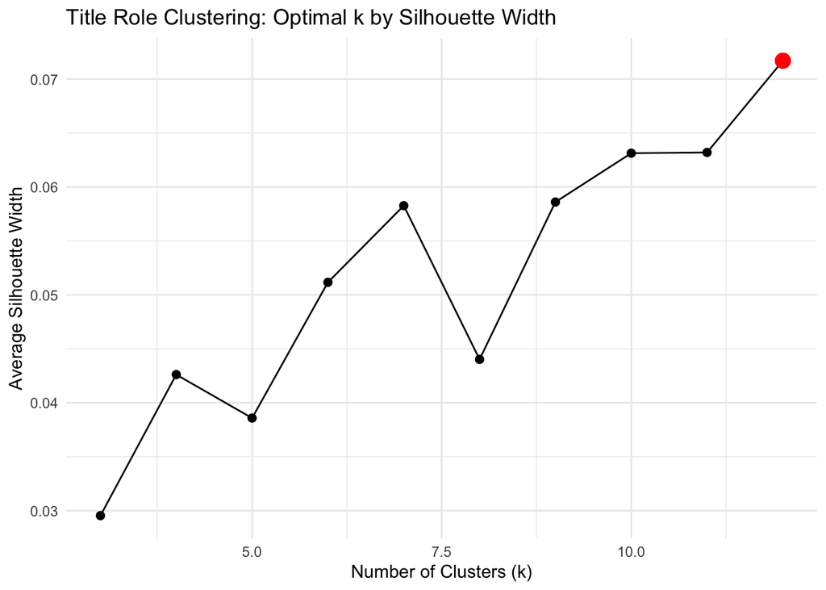

```r
sil_title <- sapply(3:12, function(k) {
  cl <- cutree(hc_title, k = k)
  mean(silhouette(cl, jacc_dist)[, "sil_width"])
})

sil_title_df <- data.frame(k = 3:12, avg_silhouette = sil_title)

ggplot(sil_title_df, aes(x = k, y = avg_silhouette)) +
  geom_line() +
  geom_point(size = 2) +
  geom_point(data = sil_title_df %>% filter(avg_silhouette == max(avg_silhouette)),
             color = "red", size = 4) +
  labs(title = "Title Role Clustering: Optimal k by Silhouette Width",
       x = "Number of Clusters (k)", y = "Average Silhouette Width") +
  theme_minimal()
```

```r
best_k_title <- sil_title_df$k[which.max(sil_title_df$avg_silhouette)]
cat("Optimal k:", best_k_title, "with avg silhouette:", max(sil_title_df$avg_silhouette))
```

```
Optimal k: 12 with avg silhouette: 0.07169934
```

Similar to the silhouette graph from Analysis 1, the graph shows how good the different number of clusters are. The higher the silhouette the better separation between groups. This silhouette has very low scores **(.03-.075 range)** peaking at k = 12. This indicates there is weak cluster structure in job titles, meaning that job titles are very heterogeneous and don’t form tight groups.

### Dendrogram

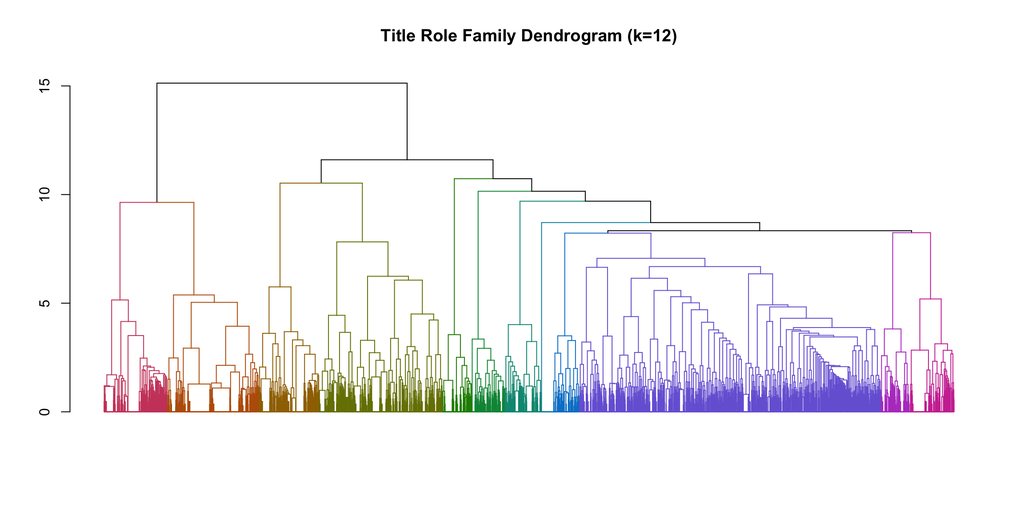

```r
dend <- as.dendrogram(hc_title)
dend <- color_branches(dend, k = best_k_title)

plot(dend, leaflab = "none",
     main = paste0("Title Role Family Dendrogram (k=", best_k_title, ")"))
```

The dendrogram is showing a hierarchical clustering of job title role families. The structure shows which roles are most similar, how groups merge together, and how distinct the clusters are. The lower joins the more similar roles, while the higher joins are more different roles. The higher level merging shows that multiple subgroups merge into broader categories and that the difference between role families exist, but they are not extremely distinct. This implies that there is gradual merging rather than clear hard splits of job title groupings.

### Cluster-Word Heatmap (What Each Role Family Means)

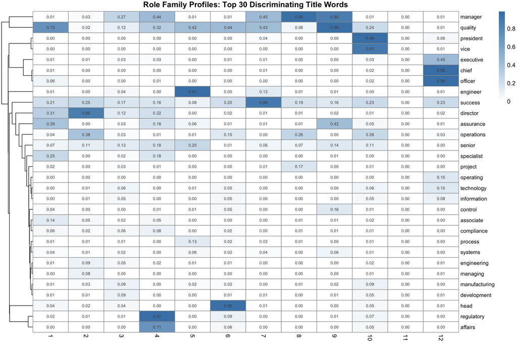

```r
title_clusters_sample <- cutree(hc_title, k = best_k_title)

# Profile each cluster by word proportion
cluster_word_props <- title_mat_sample %>%
  as.data.frame() %>%
  mutate(cluster = factor(title_clusters_sample)) %>%
  group_by(cluster) %>%
  summarise(across(everything(), mean), .groups = "drop")

# Select top 30 most discriminating words (highest variance across clusters)
word_variance <- apply(cluster_word_props[, -1], 2, var)
top_30_words <- names(sort(word_variance, decreasing = TRUE))[1:30]

heatmap_data <- cluster_word_props %>%
  select(cluster, all_of(top_30_words)) %>%
  tibble::column_to_rownames("cluster") %>%
  as.matrix()

pheatmap(t(heatmap_data),
         main = "Role Family Profiles: Top 30 Discriminating Title Words",
         cluster_rows = TRUE, cluster_cols = FALSE,
         display_numbers = TRUE, number_format = "%.2f",
         fontsize_number = 7, fontsize_row = 9,
         color = colorRampPalette(c("white", "steelblue"))(50))
```

### Assign Clusters to Full Dataset

```r
# Assign cluster labels to sampled rows, then assign remaining rows
# to nearest cluster centroid via Jaccard distance to cluster means

# Replace any NAs in title_mat with 0 (missing indicator = "not present")
title_mat[is.na(title_mat)] <- 0L

# Compute cluster centroids (mean binary vectors)
centroids <- title_mat_sample %>%
  as.data.frame() %>%
  mutate(cluster = title_clusters_sample) %>%
  group_by(cluster) %>%
  summarise(across(everything(), mean), .groups = "drop")

centroid_mat <- as.matrix(centroids[, -1])

# Assign all title rows to nearest centroid
assign_cluster <- function(row, centroids) {
  # Jaccard-like distance: 1 - (intersection / union) for binary vs continuous
  dists <- apply(centroids, 1, function(c) {
    intersection <- sum(pmin(row, c, na.rm = TRUE))
    union_val <- sum(pmax(row, c, na.rm = TRUE))
    if (is.na(union_val) || union_val == 0) return(1)
    1 - intersection / union_val
  })
  which.min(dists)
}

all_title_clusters <- apply(title_mat, 1, assign_cluster, centroids = centroid_mat)

# Add to main dataset
leads_clustered$title_cluster <- NA_integer_
title_rows <- which(leads_clustered$title_lowinfo == FALSE)
leads_clustered$title_cluster[title_rows] <- all_title_clusters
leads_clustered$title_cluster <- factor(leads_clustered$title_cluster)

table(leads_clustered$title_cluster, useNA = "ifany")
```

```
   1    2    3    4    5    6    7    8    9   10   12 <NA>
1022 1345  896  440 1012  634 1129 1550 2373  513  571 4765
```

### Conversion Rate by Role Cluster

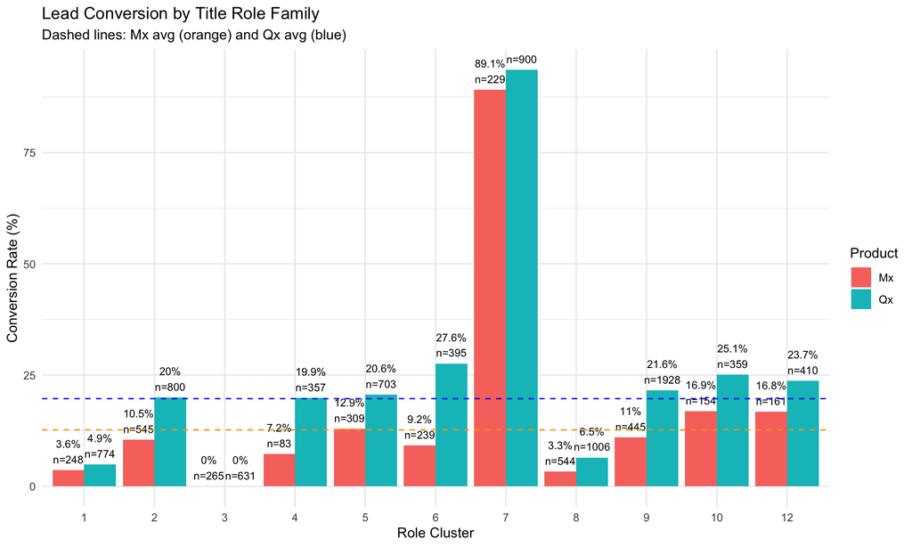

```r
title_conv <- leads_clustered %>%
  filter(!is.na(title_cluster)) %>%
  group_by(title_cluster, solution_rollup) %>%
  summarise(
    n = n(),
    conversion = mean(success) * 100,
    .groups = "drop"
  )

ggplot(title_conv, aes(x = title_cluster, y = conversion, fill = solution_rollup)) +
  geom_col(position = "dodge") +
  geom_text(aes(label = paste0(round(conversion, 1), "%\nn=", n)),
            position = position_dodge(width = 0.9), vjust = -0.3, size = 3) +
  geom_hline(yintercept = 12.7, linetype = "dashed", color = "orange") +
  geom_hline(yintercept = 19.7, linetype = "dashed", color = "blue") +
  labs(title = "Lead Conversion by Title Role Family",
       subtitle = "Dashed lines: Mx avg (orange) and Qx avg (blue)",
       x = "Role Cluster", y = "Conversion Rate (%)", fill = "Product") +
  theme_minimal()
```

This graph shows which job title converts more often by product. There are job titles/roles that are much more likely to convert. Targeting the right role matters as much as targeting the right company.

### t-SNE Visualization

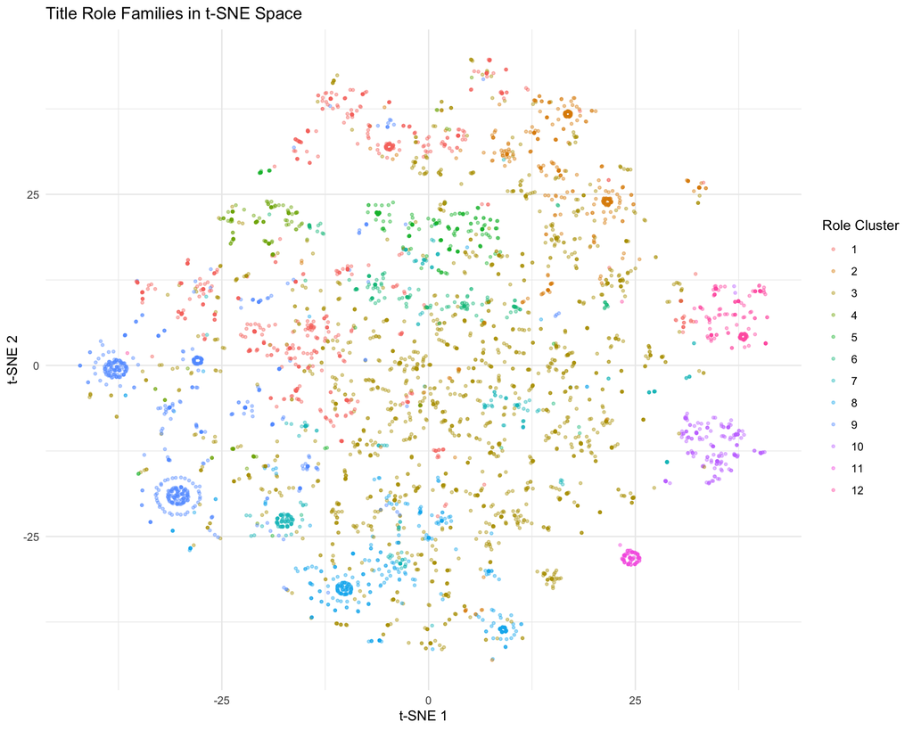

```r
set.seed(42)

# t-SNE on the sampled title data
tsne_result <- Rtsne(jacc_dist, is_distance = TRUE, perplexity = 30, dims = 2)

tsne_df <- data.frame(
  x = tsne_result$Y[, 1],
  y = tsne_result$Y[, 2],
  cluster = factor(title_clusters_sample)
)

ggplot(tsne_df, aes(x = x, y = y, color = cluster)) +
  geom_point(alpha = 0.4, size = 0.8) +
  labs(title = "Title Role Families in t-SNE Space",
       x = "t-SNE 1", y = "t-SNE 2", color = "Role Cluster") +
  theme_minimal()
```

### Role Family Summary Table

```r
# For each cluster, show top 5 defining words and conversion rates
role_summary <- leads_clustered %>%
  filter(!is.na(title_cluster)) %>%
  group_by(title_cluster) %>%
  summarise(
    n = n(),
    mx_conversion = round(mean(success[solution_rollup == "Mx"]) * 100, 2),
    qx_conversion = round(mean(success[solution_rollup == "Qx"]) * 100, 2),
    .groups = "drop"
  )

# Add top words from the heatmap data
top_words_per_cluster <- cluster_word_props %>%
  pivot_longer(-cluster, names_to = "word", values_to = "prop") %>%
  group_by(cluster) %>%
  slice_max(prop, n = 5) %>%
  summarise(top_words = paste(word, collapse = ", "), .groups = "drop")

role_summary <- role_summary %>%
  left_join(top_words_per_cluster, by = c("title_cluster" = "cluster"))

role_summary
```

```
# A tibble: 11 × 5
   title_cluster     n mx_conversion qx_conversion top_words
   <fct>         <int>         <dbl>         <dbl> <chr>
 1 1              1022          3.63          4.91 quality, assurance, director…
 2 2              1345         10.5          20    director, operations, succes…
 3 3               896          0             0    manager, success, senior, di…
 4 4               440          7.23         19.9  regulatory, affairs, manager…
 5 5              1012         12.9          20.6  engineer, quality, senior, p…
 6 6               634          9.21         27.6  head, quality, success, oper…
 7 7              1129         89.1          93.6  success, manager, quality, e…
 8 8              1550          3.31          6.46 manager, operations, success…
 9 9              2373         11.0          21.6  quality, manager, assurance,…
10 10              513         16.9          25.1  president, vice, operations,…
11 12              571         16.8          23.7  chief, officer, executive, s…
```

#### Business Translation

Each role cluster represents a distinct job function family. The conversion rates above reveal which role families are most receptive to MX vs. QX. The sales team can use these role families as targeting criteria — for example, if “Operations/Manufacturing Directors” convert at **20%**+ for MX while “Quality Specialists” convert at only **8%**, that directly informs outbound prospecting priorities.

## Analysis 3: MX-Specific Lead Profile Clustering (MCA + k-means)

This is the most directly actionable analysis. We focus exclusively on MX leads and cluster them using all available features to find distinct lead profiles, then rank profiles by conversion rate.

MCA (Multiple Correspondence Analysis) is used for dimensionality reduction — the categorical equivalent of PCA — followed by k-means on the resulting continuous dimensions.

### Prepare MX Data

```r
mx_leads <- leads_clustered %>%
  filter(solution_rollup == "Mx") %>%
  mutate(
    # Group manufacturing model to top 8 + Other + Low Info
    mfg_model_group = fct_lump_n(acct_manufacturing_model, n = 8,
                                  other_level = "Other"),
    # Group priority into 4 levels
    priority_group = case_when(
      str_detect(priority, "P1 - (Video|Live|Webinar) Demo|P1 - Website Pricing") ~ "P1 High-Intent",
      str_detect(priority, "P1 - Contact Us|P1 - MQL|P1 - Discount") ~ "P1 Standard",
      priority == "Priority 1" ~ "P1 Standard",
      priority == "Priority 2" ~ "P2",
      TRUE ~ "Low/No Priority"
    ),
    priority_group = factor(priority_group)
  )

# Select clustering features
mx_cluster_df <- mx_leads %>%
  select(acct_target_industry, mfg_model_group, site_function_group,
         acct_tier_rollup, acct_territory_rollup,
         last_tactic_campaign_channel, priority_group,
         site_or_mfg_lowinfo, title_lowinfo) %>%
  mutate(across(everything(), as.factor))

cat("Mx leads for clustering:", nrow(mx_cluster_df), "\n")
```

```
Mx leads for clustering: 4081
```

```r
cat("Features:", ncol(mx_cluster_df))
```

```
Features: 9
```

### MCA Dimensionality Reduction

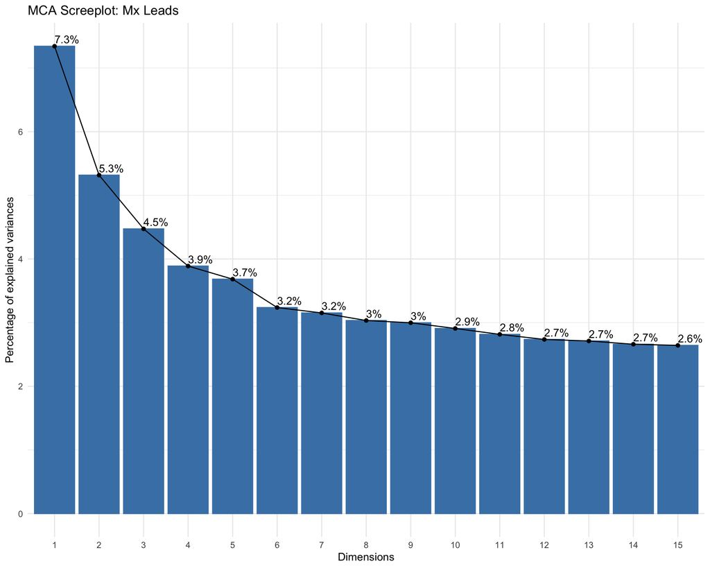

```r
mca_mx <- MCA(mx_cluster_df, graph = FALSE)

# Screeplot: how many dimensions to retain?
fviz_screeplot(mca_mx, addlabels = TRUE, ncp = 15) +
  labs(title = "MCA Screeplot: Mx Leads") +
  theme_minimal()
```

```r
# Cumulative inertia
cum_inertia <- cumsum(mca_mx$eig[, 2])
# If 70% inertia is never reached, use all available dimensions
if (any(cum_inertia >= 70)) {
  n_dim <- min(which(cum_inertia >= 70))
} else {
  n_dim <- length(cum_inertia)
}
cat("Dimensions to retain (>=70% inertia):", n_dim, "\n")
```

```
Dimensions to retain (>=70% inertia): 22
```

```r
cat("Cumulative inertia at", n_dim, "dims:", round(cum_inertia[min(n_dim, length(cum_inertia))], 1), "%")
```

```
Cumulative inertia at 22 dims: 71 %
```

### MCA Variable Biplot

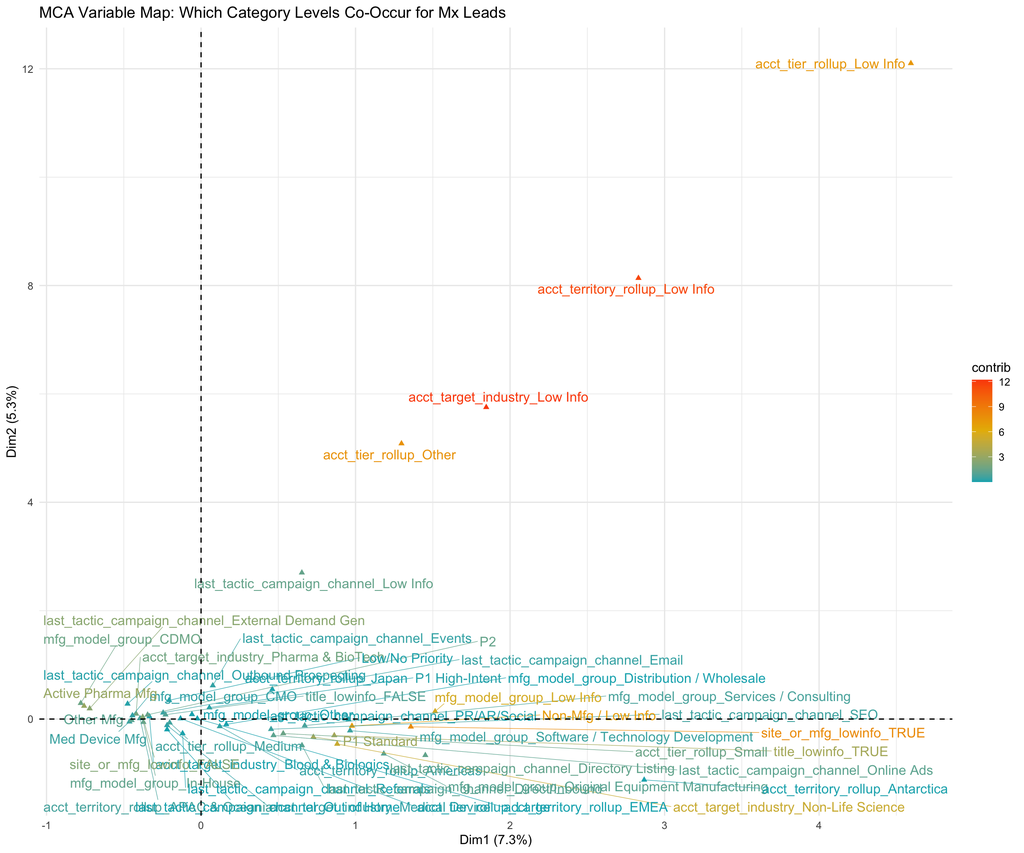

```r
fviz_mca_var(mca_mx, repel = TRUE, col.var = "contrib",
             gradient.cols = c("#00AFBB", "#E7B800", "#FC4E07")) +
  labs(title = "MCA Variable Map: Which Category Levels Co-Occur for Mx Leads") +
  theme_minimal()
```

The MCA Variable Biplot captures how categorical variable levels relate to each other in reduced-dimensional space. Each point represents a level (industry = Pharma, region = Americas, manufacturing type, job title etc). The distance between the points means the closer to each other the more similar or frequently occurring to each other. The further apart the points are, the more different they are to each other. The clusters that appear closer together tend to be the same type of leads. The points positioned far from the origin act as a strong differentiators between lead types, while centrally located variables contribute less to segmentation.

### Optimal k for k-means on MCA Scores

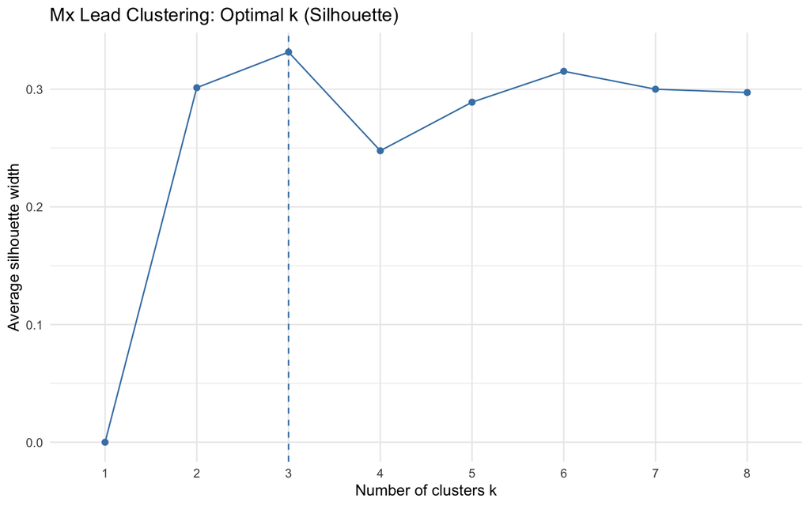

```r
# Cap at available dimensions (MCA may produce fewer than n_dim)
n_avail <- ncol(mca_mx$ind$coord)
mca_coords <- mca_mx$ind$coord[, 1:min(n_dim, n_avail, 15)]

# Silhouette method
fviz_nbclust(mca_coords, kmeans, method = "silhouette", k.max = 8) +
  labs(title = "Mx Lead Clustering: Optimal k (Silhouette)") +
  theme_minimal()
```

### Fit k-means

```r
set.seed(42)

cache_file <- file.path(cache_dir, "kmeans_mx.rds")
if (file.exists(cache_file)) {
  cached <- readRDS(cache_file)
  sil_km <- cached$sil_km
  km_mx <- cached$km_mx
  cat("Loaded km_mx from cache\n")
} else {
  # Use silhouette-optimal k
  sil_km <- sapply(2:8, function(k) {
    km <- kmeans(mca_coords, centers = k, nstart = 25)
    mean(silhouette(km$cluster, dist(mca_coords))[, "sil_width"])
  })

  best_k_mx <- (2:8)[which.max(sil_km)]
  km_mx <- kmeans(mca_coords, centers = best_k_mx, nstart = 25)

  saveRDS(list(sil_km = sil_km, km_mx = km_mx), cache_file)
  cat("Computed and cached km_mx\n")
}
```

```
Loaded km_mx from cache
```

```r
best_k_mx <- (2:8)[which.max(sil_km)]
cat("Optimal k for Mx clustering:", best_k_mx, "\n")
```

[output not shown]

```r
mx_leads$mx_cluster <- factor(km_mx$cluster)
```

### Mx Cluster Individuals in MCA Space

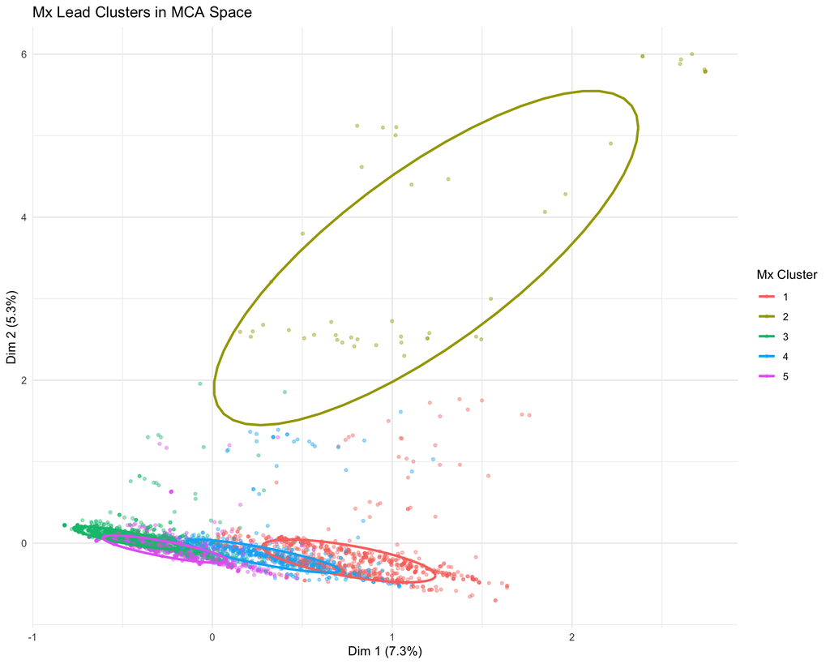

```r
mca_plot_df <- data.frame(
  Dim1 = mca_coords[, 1],
  Dim2 = mca_coords[, 2],
  cluster = mx_leads$mx_cluster
)

ggplot(mca_plot_df, aes(x = Dim1, y = Dim2, color = cluster)) +
  geom_point(alpha = 0.4, size = 1) +
  stat_ellipse(level = 0.7, linewidth = 1) +
  labs(title = "Mx Lead Clusters in MCA Space",
       x = paste0("Dim 1 (", round(mca_mx$eig[1, 2], 1), "%)"),
       y = paste0("Dim 2 (", round(mca_mx$eig[2, 2], 1), "%)"),
       color = "Mx Cluster") +
  theme_minimal()
```

Similar to the Title Job Clusters in MCA Space in Analysis 1, the MCA space reduces categorical variables into a 2 dimensional space. Each point on the plot is an account/lead. The position is based in similarity based on attributes and the color/group is each cluster assignment. As we can see, there are multiple clusters that overlap supporting the fact that the clustering is weak with not a strong distinction between each cluster.

### Mx Conversion Rate by Cluster

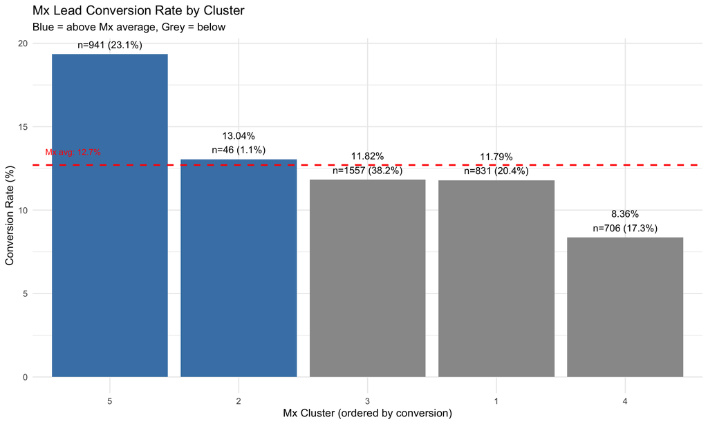

```r
mx_conv <- mx_leads %>%
  group_by(mx_cluster) %>%
  summarise(
    n = n(),
    pct_of_mx = round(100 * n() / nrow(mx_leads), 1),
    conversion = round(mean(success) * 100, 2),
    .groups = "drop"
  ) %>%
  arrange(desc(conversion))

ggplot(mx_conv, aes(x = reorder(mx_cluster, -conversion), y = conversion,
                     fill = conversion > 12.7)) +
  geom_col() +
  geom_text(aes(label = paste0(conversion, "%\nn=", n, " (", pct_of_mx, "%)")),
            vjust = -0.3, size = 3.5) +
  geom_hline(yintercept = 12.7, linetype = "dashed", color = "red", linewidth = 0.8) +
  annotate("text", x = 0.5, y = 13.5, label = "Mx avg: 12.7%", color = "red",
           hjust = 0, size = 3) +
  scale_fill_manual(values = c("TRUE" = "steelblue", "FALSE" = "grey60"),
                    guide = "none") +
  labs(title = "Mx Lead Conversion Rate by Cluster",
       subtitle = "Blue = above Mx average, Grey = below",
       x = "Mx Cluster (ordered by conversion)", y = "Conversion Rate (%)") +
  theme_minimal()
```

```r
mx_conv
```

```
# A tibble: 5 × 4
  mx_cluster     n pct_of_mx conversion
  <fct>      <int>     <dbl>      <dbl>
1 5            941      23.1      19.3
2 2             46       1.1      13.0
3 3           1557      38.2      11.8
4 1            831      20.4      11.8
5 4            706      17.3       8.36
```

### Mx Cluster Profile Summary

```r
# For each cluster, show the dominant category in each feature
mx_profiles <- mx_leads %>%
  group_by(mx_cluster) %>%
  summarise(
    n = n(),
    conversion = round(mean(success) * 100, 2),
    top_industry = names(sort(table(acct_target_industry), decreasing = TRUE))[1],
    top_mfg_model = names(sort(table(mfg_model_group), decreasing = TRUE))[1],
    top_site_fn = names(sort(table(site_function_group), decreasing = TRUE))[1],
    top_tier = names(sort(table(acct_tier_rollup), decreasing = TRUE))[1],
    top_territory = names(sort(table(acct_territory_rollup), decreasing = TRUE))[1],
    top_channel = names(sort(table(last_tactic_campaign_channel), decreasing = TRUE))[1],
    top_priority = names(sort(table(priority_group), decreasing = TRUE))[1],
    pct_lowinfo = round(mean(site_or_mfg_lowinfo == TRUE) * 100, 1),
    .groups = "drop"
  ) %>%
  arrange(desc(conversion))

mx_profiles
```

```
# A tibble: 5 × 11
  mx_cluster     n conversion top_industry    top_mfg_model top_site_fn top_tier
  <fct>      <int>      <dbl> <chr>           <chr>         <chr>       <chr>
1 5            941      19.3  Medical Device  In-House      Other Mfg   Medium
2 2             46      13.0  Low Info        Low Info      Non-Mfg / … Other
3 3           1557      11.8  Pharma & BioTe… In-House      Active Pha… Medium
4 1            831      11.8  Non-Life Scien… Low Info      Non-Mfg / … Medium
5 4            706       8.36 Non-Life Scien… Services / C… Non-Mfg / … Medium
# ℹ 4 more variables: top_territory <chr>, top_channel <chr>,
#   top_priority <chr>, pct_lowinfo <dbl>
```

#### Business Translation

The clusters above represent distinct MX lead archetypes. The highest-converting cluster(s) reveal the “golden MX profile” — the combination of industry, company type, channel, and priority that sales should prioritize. Low-converting clusters (especially those with high % Low Info) represent leads where current targeting is inefficient. If MasterControl shifts MX outreach toward the highest-converting cluster, the overall MX progression rate can move toward the **16-18%** target.

## Analysis 4: Success Profile Clustering — ICP Discovery (Gower + PAM)

We cluster ONLY successful MX leads (SQL/SQO/Won) to reverse-engineer the Ideal Customer Profile. With only ~529 successes, PAM is ideal — the medoid of each cluster is a real winning lead that serves as a concrete archetype.

### Prepare Successful Mx Leads

```r
mx_success <- leads_clustered %>%
  filter(solution_rollup == "Mx",
         next_stage_c %in% c("SQL", "SQO", "Won")) %>%
  mutate(
    mfg_model_group = fct_lump_n(acct_manufacturing_model, n = 8,
                                  other_level = "Other"),
    priority_group = case_when(
      str_detect(priority, "P1 - (Video|Live|Webinar) Demo|P1 - Website Pricing") ~ "P1 High-Intent",
      str_detect(priority, "P1 - Contact Us|P1 - MQL|P1 - Discount") ~ "P1 Standard",
      priority == "Priority 1" ~ "P1 Standard",
      priority == "Priority 2" ~ "P2",
      TRUE ~ "Low/No Priority"
    )
  )

cat("Successful Mx leads:", nrow(mx_success))
```

```
Successful Mx leads: 529
```

### Select ICP Features

```r
# Top title word indicators for ICP analysis
top_title_words <- c("quality", "manager", "director", "operations",
                     "manufacturing", "regulatory", "vice", "president",
                     "engineer", "senior", "compliance", "systems",
                     "specialist", "chief", "lead")

# Only include title words that exist in the dataset
available_title_words <- intersect(top_title_words, names(mx_success))

icp_df <- mx_success %>%
  select(acct_target_industry, mfg_model_group, site_function_group,
         acct_tier_rollup, acct_territory_rollup,
         last_tactic_campaign_channel, priority_group,
         all_of(available_title_words)) %>%
  mutate(across(where(is.character), as.factor),
         across(where(is.numeric), as.factor))

cat("ICP features:", ncol(icp_df), "\n")
```

```
ICP features: 22
```

```r
cat("Successful Mx leads:", nrow(icp_df))
```

```
Successful Mx leads: 529
```

### Gower Distance + Optimal k

```r
cache_file <- file.path(cache_dir, "gower_icp.rds")
if (file.exists(cache_file)) {
  cached <- readRDS(cache_file)
  gower_icp <- cached$gower_icp
  sil_icp <- cached$sil_icp
  cat("Loaded gower_icp and sil_icp from cache\n")
} else {
  gower_icp <- daisy(icp_df, metric = "gower")

  sil_icp <- sapply(2:6, function(k) {
    pam_fit <- pam(gower_icp, k = k, diss = TRUE)
    pam_fit$silinfo$avg.width
  })

  saveRDS(list(gower_icp = gower_icp, sil_icp = sil_icp), cache_file)
  cat("Computed and cached gower_icp and sil_icp\n")
}
```

```
Loaded gower_icp and sil_icp from cache
```

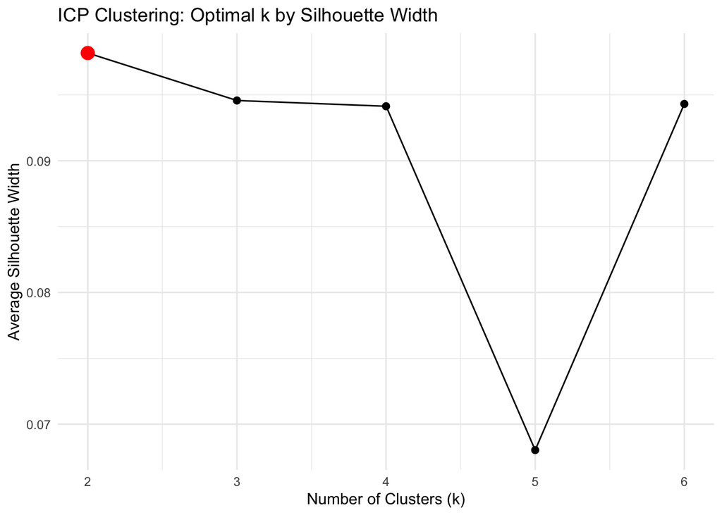

```r
sil_icp_df <- data.frame(k = 2:6, avg_silhouette = sil_icp)

ggplot(sil_icp_df, aes(x = k, y = avg_silhouette)) +
  geom_line() +
  geom_point(size = 2) +
  geom_point(data = sil_icp_df %>% filter(avg_silhouette == max(avg_silhouette)),
             color = "red", size = 4) +
  labs(title = "ICP Clustering: Optimal k by Silhouette Width",
       x = "Number of Clusters (k)", y = "Average Silhouette Width") +
  theme_minimal()
```

```r
best_k_icp <- sil_icp_df$k[which.max(sil_icp_df$avg_silhouette)]
cat("Optimal k for ICP:", best_k_icp, "with avg silhouette:", max(sil_icp_df$avg_silhouette))
```

```
Optimal k for ICP: 2 with avg silhouette: 0.0981777
```

Similar to other silhouette analyses, the silhouette range is very low **(~.1 to .1)**. The successful leads don’t form distinct internal clusters. They are relatively homogeneous, which makes sense; successful leads share a common profile. The optimal k value is 2 with a score of .1.

### Fit PAM and Extract ICPs

```
  cluster size ave.sil.width
1       1  366          0.08
2       2  163          0.13
```

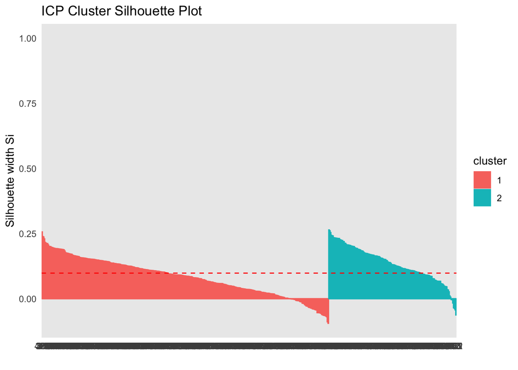

```r
pam_icp <- pam(gower_icp, k = best_k_icp, diss = TRUE)

mx_success$icp_cluster <- factor(pam_icp$clustering)

# Silhouette plot
fviz_silhouette(pam_icp) +
  labs(title = "ICP Cluster Silhouette Plot") +
  theme_minimal()
```

This graph shows how well each individual data point fits into its assigned cluster. At k = 2 (2 clusters) and a score of **.1**. As stated in the previous analysis plot, having a score of **.1** indicates weak separation between clusters. This suggests that successful leads do not naturally split into clearly distinct subgroups, instead appear relatively homogeneous, which aligns with what was stated in analysis 1 that successful leads share a consistent customer profile.

### ICP Archetype Table (Medoid Profiles)

```r
# Each medoid IS a real winning Mx lead — the concrete archetype
medoid_icp_rows <- pam_icp$id.med
icp_archetypes <- mx_success[medoid_icp_rows, ] %>%
  select(icp_cluster, acct_target_industry, mfg_model_group, site_function_group,
         acct_tier_rollup, acct_territory_rollup,
         last_tactic_campaign_channel, priority_group,
         contact_lead_title)

icp_archetypes
```

```
    icp_cluster acct_target_industry mfg_model_group site_function_group
488           1       Medical Device        In-House           Other Mfg
526           2     Pharma & BioTech            CDMO   Active Pharma Mfg
    acct_tier_rollup acct_territory_rollup last_tactic_campaign_channel
488           Medium              Americas                   Online Ads
526           Medium              Americas                          SEO
    priority_group    contact_lead_title
488    P1 Standard              Low Info
526    P1 Standard research scientist ii
```

### ICP Cluster Composition vs. Overall MX Population

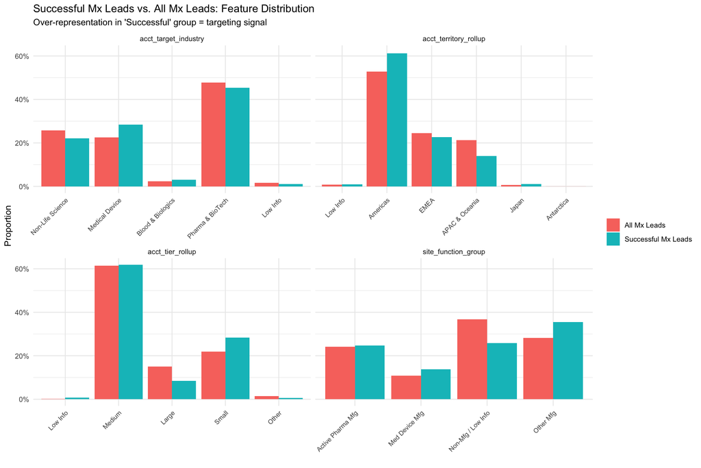

```r
# Compare: what % of successful Mx leads are in each category vs. all Mx leads?
mx_all_with_cluster <- leads_clustered %>%
  filter(solution_rollup == "Mx") %>%
  mutate(
    mfg_model_group = fct_lump_n(acct_manufacturing_model, n = 8, other_level = "Other")
  )

compare_vars <- c("acct_target_industry", "site_function_group", "acct_tier_rollup",
                   "acct_territory_rollup")

comparison_data <- bind_rows(
  mx_all_with_cluster %>%
    select(all_of(compare_vars)) %>%
    pivot_longer(everything(), names_to = "variable", values_to = "level") %>%
    count(variable, level) %>%
    group_by(variable) %>%
    mutate(prop = n / sum(n), group = "All Mx Leads") %>%
    ungroup(),
  mx_success %>%
    select(all_of(compare_vars)) %>%
    pivot_longer(everything(), names_to = "variable", values_to = "level") %>%
    count(variable, level) %>%
    group_by(variable) %>%
    mutate(prop = n / sum(n), group = "Successful Mx Leads") %>%
    ungroup()
)

ggplot(comparison_data, aes(x = level, y = prop, fill = group)) +
  geom_col(position = "dodge") +
  facet_wrap(~ variable, scales = "free_x") +
  scale_y_continuous(labels = scales::percent) +
  labs(title = "Successful Mx Leads vs. All Mx Leads: Feature Distribution",
       subtitle = "Over-representation in 'Successful' group = targeting signal",
       x = "", y = "Proportion", fill = "") +
  theme_minimal() +
  theme(axis.text.x = element_text(angle = 45, hjust = 1, size = 8))
```

### ICP Cluster Summary

```r
icp_summary <- mx_success %>%
  group_by(icp_cluster) %>%
  summarise(
    n = n(),
    pct_of_winners = round(100 * n() / nrow(mx_success), 1),
    top_industry = names(sort(table(acct_target_industry), decreasing = TRUE))[1],
    top_mfg = names(sort(table(mfg_model_group), decreasing = TRUE))[1],
    top_site_fn = names(sort(table(site_function_group), decreasing = TRUE))[1],
    top_tier = names(sort(table(acct_tier_rollup), decreasing = TRUE))[1],
    top_territory = names(sort(table(acct_territory_rollup), decreasing = TRUE))[1],
    top_channel = names(sort(table(last_tactic_campaign_channel), decreasing = TRUE))[1],
    .groups = "drop"
  )

icp_summary
```

```
# A tibble: 2 × 9
  icp_cluster     n pct_of_winners top_industry     top_mfg top_site_fn top_tier
  <fct>       <int>          <dbl> <chr>            <chr>   <chr>       <chr>
1 1             366           69.2 Medical Device   In-Hou… Other Mfg   Medium
2 2             163           30.8 Pharma & BioTech CDMO    Active Pha… Medium
# ℹ 2 more variables: top_territory <chr>, top_channel <chr>
```

```r
#save clustered features for use in modeling
saveRDS(
  leads_clustered %>% select(qal_id, account_cluster, title_cluster),
  "data/cluster_labels.rds"
)
saveRDS(
  mx_leads %>% select(qal_id, mx_cluster),
  "data/mx_cluster_labels.rds"
)
```

#### Business Translation

Each ICP cluster is a data-driven Ideal Customer Profile for MX. The medoid archetype gives the sales team a concrete example: “This exact type of lead, with this title, at this type of company, arriving via this channel, converted.” The comparison chart shows which attributes are over-represented among winners relative to all MX leads — these are the attributes to prioritize in targeting. If **60%** of current MX leads match no ICP cluster, that quantifies the targeting waste and the opportunity for improvement.

## Results Overview Summary

**Data Problems:**

- Missing data was not random and has a pattern; ‘Low Info’ records represent incomplete enrichment or lead source characteristics and should be treated as predictive signals rather than removed from the dataset.
- Missing site/manufacturing was found to most likely come from small tier, which contracts our Ideal Customer Profile Cluster analysis which states small-to-medium tier is best. This will be further analyzed when we perform modeling on the dataset to gain firmer confirmation.
- High variability in job titles created noise; standardizing titles and using bi-grams improved feature clarity and reduced job title complexity for modeling.
- We are grouping these leads together and should be treated as a signal rather than these be excluded from the analysis.
- As stated in the analysis, ‘Missing Info or Low Info’ leads pattern is telling us something about the lead itself and how it entered the system. In practice, missing enrichment can be treated like a warning sign that the lead may be lower quality or less well-qualified, or that the channel/source collects less complete information.

**Structural Patterns from Clustering:**

- Successful leads are relatively homogeneous (ow silhouette score of .1) suggesting a consistent ideal customer profile (ICP) rather than multiple distinct ideal customer profile subgroups.
- The ideal MX customer profile is clear; Americas-based, small-to-medium, Pharma/Bio Tech or Medical Device companies.

**Impact on Analytics Approach:**

- Targeting the right job title matters as much as targeting the right company/industry.
- Job title and industry will be the key components in our analytic approach to ensure we are targeting leads that are most likely to convert.
- Missing/Low Info indicators will be retained allowing models to learn relationships between enrichment quality and conversion outcomes.
- During modeling, looking we include Small Tier companies and their likelihood of converting to ensure consistency.